# Breast Cancer Diagnosis Using Machine Learning

### **Dataset Source**

The dataset used in this project is the **Breast Cancer Wisconsin (Diagnostic) Dataset (WDBC)** obtained from the **UCI Machine Learning Repository.**

**Data Description**

The dataset contains 569 instances with 30 numerical features derived from digitized images of fine needle aspiration (FNA) of breast masses. The target variable represents tumor diagnosis:

- **M = Malignant**
- **B = Benign**

This dataset is publicly available and widely used for machine learning research and academic purposes.

## Problem Statement

### **Business / Healthcare Context**

Breast cancer is one of the most common and serious health conditions affecting women worldwide. It occurs when abnormal breast cells grow uncontrollably and form malignant tumors, which can spread to other parts of the body if not detected early. Clinical research has consistently shown that early detection significantly improves survival rates, reduces the need for aggressive treatment, and leads to better long-term patient outcomes.

Modern diagnostic procedures, such as fine needle aspirate (FNA) biopsies, generate a large number of quantitative measurements describing tumor characteristics related to size, shape, texture, and structural irregularities. While these measurements contain valuable diagnostic information, manually interpreting complex patterns across many features can be challenging, time-consuming, and subject to variability across practitioners.

### **Problem Definition**

The key challenge addressed in this project is to determine whether supervised machine learning models, trained on structured diagnostic data derived from FNA biopsies, can accurately and reliably distinguish between benign and malignant breast tumors. Improving the accuracy and consistency of tumor classification can support early diagnosis and help prioritize high-risk cases for further clinical evaluation.

### **Project Objective**

You are working as a **data analyst/data scientist in a healthcare analytics context**. Your task is to analyze a publicly available breast cancer diagnostic dataset and develop machine learning classification models that can assist in identifying malignant tumors with high predictive performance.

Specifically, this project aims to:

- Identify the most influential diagnostic features associated with breast cancer malignancy
- Build supervised machine learning classification models to predict tumor diagnosis
- Compare the performance of multiple models using appropriate evaluation metrics
- Examine whether a reduced set of diagnostic features can maintain reliable predictive accuracy

### **Expected Outcome**

The outcome of this project is a set of **evaluated and interpretable machine learning models** that demonstrate the feasibility of using structured diagnostic data for early breast cancer detection. While the models developed are **not intended for direct clinical deployment**, they illustrate how analytics and machine learning can serve as **decision-support tools** to complement clinical expertise.

### **Scope of the Study**

The scope of this project is limited to the analysis of structured numerical data derived from digitized images of fine needle aspirate (FNA) biopsies. The dataset consists exclusively of quantitative diagnostic features describing tumor size, shape, and texture, with no use of medical images or unstructured clinical notes. The analysis is conducted using a publicly available breast cancer diagnostic dataset and is designed to be completed within an academic capstone timeframe.

### **Project Objectives**

The primary objectives of this study are to:

- Identify diagnostic features that are strongly associated with breast cancer malignancy
- Develop supervised machine learning models to classify tumors as benign or malignant
- Compare predictive performance across multiple classification models
- Explore feature importance to assess whether a reduced subset of features can support reliable prediction performance

### **Research Focus and Methodological Alignment**

To address these objectives, the project follows an exploratory and model-driven analytical approach. Feature relevance is examined using correlation analysis and tree-based feature importance methods. Classification performance is evaluated using multiple supervised learning models, and comparative performance is assessed using standard evaluation metrics such as accuracy, recall, F1-score, and AUC-ROC.

Rather than formal statistical hypothesis testing, the analysis emphasizes empirical model performance and interpretability, which aligns with common practices in applied machine learning and healthcare analytics.

```python
# Installing the libraries with the specified version.
!pip install scikit-learn seaborn matplotlib numpy pandas imbalanced-learn xgboost --user
```

## Import Libraries

```python
# Libraries to help with reading and manipulating data
import pandas as pd
import numpy as np

# Libaries to help with data visualization
import matplotlib.pyplot as plt
import seaborn as sns

# To tune model, get different metric scores, and split data
from sklearn.metrics import (
    f1_score,
    accuracy_score,
    recall_score,
    precision_score,
    confusion_matrix,
    roc_auc_score,
    ConfusionMatrixDisplay,
)
from sklearn.model_selection import train_test_split, StratifiedKFold, cross_val_score

# To be used for data scaling and one hot encoding
from sklearn.preprocessing import StandardScaler, MinMaxScaler, OneHotEncoder

# To impute missing values
from sklearn.impute import SimpleImputer
from sklearn import metrics

# To oversample and undersample data
from imblearn.over_sampling import SMOTE
from imblearn.under_sampling import RandomUnderSampler

# To do hyperparameter tuning
from sklearn.model_selection import RandomizedSearchCV

# To define maximum number of columns to be displayed in a dataframe
pd.set_option("display.max_columns", None)

# To supress scientific notations for a dataframe
pd.set_option("display.float_format", lambda x: "%.3f" % x)

# To help with model building
from sklearn.tree import DecisionTreeClassifier
from sklearn.ensemble import (
    AdaBoostClassifier,
    GradientBoostingClassifier,
    RandomForestClassifier,
    BaggingClassifier,
)
from xgboost import XGBClassifier
from sklearn.linear_model import LogisticRegression

# To suppress scientific notations
pd.set_option("display.float_format", lambda x: "%.3f" % x)

# To supress warnings
import warnings

warnings.filterwarnings("ignore")
```

```python
data = pd.read_csv("wdbc.data", header=None)
```

```python
data.head()
```

|  | 0 | 1 | 2 | 3 | 4 | 5 | 6 | 7 | 8 | 9 | 10 | 11 | 12 | 13 | 14 | 15 | 16 | 17 | 18 | 19 | 20 | 21 | 22 | 23 | 24 | 25 | 26 | 27 | 28 | … |
| --- | --- | --- | --- | --- | --- | --- | --- | --- | --- | --- | --- | --- | --- | --- | --- | --- | --- | --- | --- | --- | --- | --- | --- | --- | --- | --- | --- | --- | --- | --- |
| 0 | 842302 | M | 17.990 | 10.380 | 122.800 | 1001.000 | 0.118 | 0.278 | 0.300 | 0.147 | 0.242 | 0.079 | 1.095 | 0.905 | 8.589 | 153.400 | 0.006 | 0.049 | 0.054 | 0.016 | 0.030 | 0.006 | 25.380 | 17.330 | 184.600 | 2019.000 | 0.162 | 0.666 | 0.712 | … |
| 1 | 842517 | M | 20.570 | 17.770 | 132.900 | 1326.000 | 0.085 | 0.079 | 0.087 | 0.070 | 0.181 | 0.057 | 0.543 | 0.734 | 3.398 | 74.080 | 0.005 | 0.013 | 0.019 | 0.013 | 0.014 | 0.004 | 24.990 | 23.410 | 158.800 | 1956.000 | 0.124 | 0.187 | 0.242 | … |
| 2 | 84300903 | M | 19.690 | 21.250 | 130.000 | 1203.000 | 0.110 | 0.160 | 0.197 | 0.128 | 0.207 | 0.060 | 0.746 | 0.787 | 4.585 | 94.030 | 0.006 | 0.040 | 0.038 | 0.021 | 0.022 | 0.005 | 23.570 | 25.530 | 152.500 | 1709.000 | 0.144 | 0.424 | 0.450 | … |
| 3 | 84348301 | M | 11.420 | 20.380 | 77.580 | 386.100 | 0.142 | 0.284 | 0.241 | 0.105 | 0.260 | 0.097 | 0.496 | 1.156 | 3.445 | 27.230 | 0.009 | 0.075 | 0.057 | 0.019 | 0.060 | 0.009 | 14.910 | 26.500 | 98.870 | 567.700 | 0.210 | 0.866 | 0.687 | … |
| 4 | 84358402 | M | 20.290 | 14.340 | 135.100 | 1297.000 | 0.100 | 0.133 | 0.198 | 0.104 | 0.181 | 0.059 | 0.757 | 0.781 | 5.438 | 94.440 | 0.011 | 0.025 | 0.057 | 0.019 | 0.018 | 0.005 | 22.540 | 16.670 | 152.200 | 1575.000 | 0.137 | 0.205 | 0.400 | … |

```python
columns = [
    "ID",
    "Diagnosis",  # M = malignant, B = benign
    "radius_mean", "texture_mean", "perimeter_mean", "area_mean", "smoothness_mean",
    "compactness_mean", "concavity_mean", "concave_points_mean", "symmetry_mean", "fractal_dimension_mean",
    "radius_se", "texture_se", "perimeter_se", "area_se", "smoothness_se",
    "compactness_se", "concavity_se", "concave_points_se", "symmetry_se", "fractal_dimension_se",
    "radius_worst", "texture_worst", "perimeter_worst", "area_worst", "smoothness_worst",
    "compactness_worst", "concavity_worst", "concave_points_worst", "symmetry_worst", "fractal_dimension_worst"
]

data.columns = columns
```

```python
data.to_csv("wdbc.csv", index=False)
```

```python
files.download("wdbc.csv")
```

```python
data.head()
```

|  | ID | Diagnosis | radius_mean | texture_mean | perimeter_mean | area_mean | smoothness_mean | compactness_mean | concavity_mean | concave_points_mean | symmetry_mean | fractal_dimension_mean | radius_se | texture_se | perimeter_se | area_se | smoothness_se | compactness_se | concavity_se | concave_points_se | symmetry_se | fractal_dimension_se | radius_worst | texture_worst | perimeter_worst | area_worst | smoothness_worst | compactness_worst | concavity_worst | … |
| --- | --- | --- | --- | --- | --- | --- | --- | --- | --- | --- | --- | --- | --- | --- | --- | --- | --- | --- | --- | --- | --- | --- | --- | --- | --- | --- | --- | --- | --- | --- |
| 0 | 842302 | M | 17.990 | 10.380 | 122.800 | 1001.000 | 0.118 | 0.278 | 0.300 | 0.147 | 0.242 | 0.079 | 1.095 | 0.905 | 8.589 | 153.400 | 0.006 | 0.049 | 0.054 | 0.016 | 0.030 | 0.006 | 25.380 | 17.330 | 184.600 | 2019.000 | 0.162 | 0.666 | 0.712 | … |
| 1 | 842517 | M | 20.570 | 17.770 | 132.900 | 1326.000 | 0.085 | 0.079 | 0.087 | 0.070 | 0.181 | 0.057 | 0.543 | 0.734 | 3.398 | 74.080 | 0.005 | 0.013 | 0.019 | 0.013 | 0.014 | 0.004 | 24.990 | 23.410 | 158.800 | 1956.000 | 0.124 | 0.187 | 0.242 | … |
| 2 | 84300903 | M | 19.690 | 21.250 | 130.000 | 1203.000 | 0.110 | 0.160 | 0.197 | 0.128 | 0.207 | 0.060 | 0.746 | 0.787 | 4.585 | 94.030 | 0.006 | 0.040 | 0.038 | 0.021 | 0.022 | 0.005 | 23.570 | 25.530 | 152.500 | 1709.000 | 0.144 | 0.424 | 0.450 | … |
| 3 | 84348301 | M | 11.420 | 20.380 | 77.580 | 386.100 | 0.142 | 0.284 | 0.241 | 0.105 | 0.260 | 0.097 | 0.496 | 1.156 | 3.445 | 27.230 | 0.009 | 0.075 | 0.057 | 0.019 | 0.060 | 0.009 | 14.910 | 26.500 | 98.870 | 567.700 | 0.210 | 0.866 | 0.687 | … |
| 4 | 84358402 | M | 20.290 | 14.340 | 135.100 | 1297.000 | 0.100 | 0.133 | 0.198 | 0.104 | 0.181 | 0.059 | 0.757 | 0.781 | 5.438 | 94.440 | 0.011 | 0.025 | 0.057 | 0.019 | 0.018 | 0.005 | 22.540 | 16.670 | 152.200 | 1575.000 | 0.137 | 0.205 | 0.400 | … |

```python
data.head(2)
```

|  | ID | Diagnosis | radius_mean | texture_mean | perimeter_mean | area_mean | smoothness_mean | compactness_mean | concavity_mean | concave_points_mean | symmetry_mean | fractal_dimension_mean | radius_se | texture_se | perimeter_se | area_se | smoothness_se | compactness_se | concavity_se | concave_points_se | symmetry_se | fractal_dimension_se | radius_worst | texture_worst | perimeter_worst | area_worst | smoothness_worst | compactness_worst | concavity_worst | … |
| --- | --- | --- | --- | --- | --- | --- | --- | --- | --- | --- | --- | --- | --- | --- | --- | --- | --- | --- | --- | --- | --- | --- | --- | --- | --- | --- | --- | --- | --- | --- |
| 0 | 842302 | M | 17.990 | 10.380 | 122.800 | 1001.000 | 0.118 | 0.278 | 0.300 | 0.147 | 0.242 | 0.079 | 1.095 | 0.905 | 8.589 | 153.400 | 0.006 | 0.049 | 0.054 | 0.016 | 0.030 | 0.006 | 25.380 | 17.330 | 184.600 | 2019.000 | 0.162 | 0.666 | 0.712 | … |
| 1 | 842517 | M | 20.570 | 17.770 | 132.900 | 1326.000 | 0.085 | 0.079 | 0.087 | 0.070 | 0.181 | 0.057 | 0.543 | 0.734 | 3.398 | 74.080 | 0.005 | 0.013 | 0.019 | 0.013 | 0.014 | 0.004 | 24.990 | 23.410 | 158.800 | 1956.000 | 0.124 | 0.187 | 0.242 | … |

```python
data.shape
```

```
(569, 32)
```

### Observations

- This data set has 569 rows and 32 columns

```python
data.info()
```

```
<class 'pandas.core.frame.DataFrame'>
RangeIndex: 569 entries, 0 to 568
Data columns (total 32 columns):
 #   Column                   Non-Null Count  Dtype
---  ------                   --------------  -----
 0   ID                       569 non-null    int64
 1   Diagnosis                569 non-null    object
 2   radius_mean              569 non-null    float64
 3   texture_mean             569 non-null    float64
 4   perimeter_mean           569 non-null    float64
 5   area_mean                569 non-null    float64
 6   smoothness_mean          569 non-null    float64
 7   compactness_mean         569 non-null    float64
 8   concavity_mean           569 non-null    float64
 9   concave_points_mean      569 non-null    float64
```

[output cut: 24 more lines]

### Observations

- The dataset has 569 records and 32 columns. There are no missing values. One column is an ID, one is the target variable (Diagnosis), and the remaining 30 are numeric medical features. I will drop the ID column, encode the Diagnosis column, and perform EDA mainly on selected important features and overall statistics rather than analyzing all 30 individually.

```python
#Checking for missing values

missing_values = data.isnull().sum()
print("Missing values in each column:\n", missing_values)
```

```
Missing values in each column:
 ID                         0
Diagnosis                  0
radius_mean                0
texture_mean               0
perimeter_mean             0
area_mean                  0
smoothness_mean            0
compactness_mean           0
concavity_mean             0
concave_points_mean        0
symmetry_mean              0
fractal_dimension_mean     0
radius_se                  0
texture_se                 0
perimeter_se               0
area_se                    0
smoothness_se              0
compactness_se             0
concavity_se               0
concave_points_se          0
symmetry_se                0
fractal_dimension_se       0
radius_worst               0
texture_worst              0
perimeter_worst            0
area_worst                 0
smoothness_worst           0
compactness_worst          0
concavity_worst            0
concave_points_worst       0
symmetry_worst             0
fractal_dimension_worst    0
dtype: int64
```

### Observations

- No Missing Values

```python
data.describe()
```

|  | ID | radius_mean | texture_mean | perimeter_mean | area_mean | smoothness_mean | compactness_mean | concavity_mean | concave_points_mean | symmetry_mean | ... | radius_worst | texture_worst | perimeter_worst | area_worst | smoothness_worst | compactness_worst | concavity_worst | concave_points_worst | symmetry_worst | fractal_dimension_worst |
| --- | --- | --- | --- | --- | --- | --- | --- | --- | --- | --- | --- | --- | --- | --- | --- | --- | --- | --- | --- | --- | --- |
| count | 5.690000e+02 | 569.000000 | 569.000000 | 569.000000 | 569.000000 | 569.000000 | 569.000000 | 569.000000 | 569.000000 | 569.000000 | ... | 569.000000 | 569.000000 | 569.000000 | 569.000000 | 569.000000 | 569.000000 | 569.000000 | 569.000000 | 569.000000 | 569.000000 |
| mean | 3.037183e+07 | 14.127292 | 19.289649 | 91.969033 | 654.889104 | 0.096360 | 0.104341 | 0.088799 | 0.048919 | 0.181162 | ... | 16.269190 | 25.677223 | 107.261213 | 880.583128 | 0.132369 | 0.254265 | 0.272188 | 0.114606 | 0.290076 | 0.083946 |
| std | 1.250206e+08 | 3.524049 | 4.301036 | 24.298981 | 351.914129 | 0.014064 | 0.052813 | 0.079720 | 0.038803 | 0.027414 | ... | 4.833242 | 6.146258 | 33.602542 | 569.356993 | 0.022832 | 0.157336 | 0.208624 | 0.065732 | 0.061867 | 0.018061 |
| min | 8.670000e+03 | 6.981000 | 9.710000 | 43.790000 | 143.500000 | 0.052630 | 0.019380 | 0.000000 | 0.000000 | 0.106000 | ... | 7.930000 | 12.020000 | 50.410000 | 185.200000 | 0.071170 | 0.027290 | 0.000000 | 0.000000 | 0.156500 | 0.055040 |
| 25% | 8.692180e+05 | 11.700000 | 16.170000 | 75.170000 | 420.300000 | 0.086370 | 0.064920 | 0.029560 | 0.020310 | 0.161900 | ... | 13.010000 | 21.080000 | 84.110000 | 515.300000 | 0.116600 | 0.147200 | 0.114500 | 0.064930 | 0.250400 | 0.071460 |
| 50% | 9.060240e+05 | 13.370000 | 18.840000 | 86.240000 | 551.100000 | 0.095870 | 0.092630 | 0.061540 | 0.033500 | 0.179200 | ... | 14.970000 | 25.410000 | 97.660000 | 686.500000 | 0.131300 | 0.211900 | 0.226700 | 0.099930 | 0.282200 | 0.080040 |
| 75% | 8.813129e+06 | 15.780000 | 21.800000 | 104.100000 | 782.700000 | 0.105300 | 0.130400 | 0.130700 | 0.074000 | 0.195700 | ... | 18.790000 | 29.720000 | 125.400000 | 1084.000000 | 0.146000 | 0.339100 | 0.382900 | 0.161400 | 0.317900 | 0.092080 |
| max | 9.113205e+08 | 28.110000 | 39.280000 | 188.500000 | 2501.000000 | 0.163400 | 0.345400 | 0.426800 | 0.201200 | 0.304000 | ... | 36.040000 | 49.540000 | 251.200000 | 4254.000000 | 0.222600 | 1.058000 | 1.252000 | 0.291000 | 0.663800 | 0.207500 |

8 rows × 31 columns

### Observations (Summary)

- Tumor size–related features such as **radius, perimeter, and area** show a wide range of values, indicating high variability across patients.
- **Worst-case measurements** are consistently higher than their corresponding mean values, which aligns with the medical definition of these features.
- Several shape-related features, including **concavity and concave points**, have minimum values of zero, indicating absence of these characteristics in some tumors.
- Some **worst features** (especially compactness and concavity) show very high maximum values, suggesting the presence of potential outliers.
- All numeric features have valid ranges with no missing values, confirming the dataset is clean and suitable for further analysis and modeling.

Overall, the data shows strong variability in tumor size and shape, clear differences between mean and worst measurements, and no missing values, making it well suited for classification modeling.

```python
# Checking for unique values in the data set

data.nunique()
```

|  | 0 |
| --- | --- |
| ID | 569 |
| Diagnosis | 2 |
| radius_mean | 456 |
| texture_mean | 479 |
| perimeter_mean | 522 |
| area_mean | 539 |
| smoothness_mean | 474 |
| compactness_mean | 537 |
| concavity_mean | 537 |
| concave_points_mean | 542 |
| symmetry_mean | 432 |
| fractal_dimension_mean | 499 |
| radius_se | 540 |
| texture_se | 519 |
| perimeter_se | 533 |
| area_se | 528 |
| smoothness_se | 547 |
| compactness_se | 541 |
| concavity_se | 533 |
| concave_points_se | 507 |
| symmetry_se | 498 |
| fractal_dimension_se | 545 |
| radius_worst | 457 |
| texture_worst | 511 |
| perimeter_worst | 514 |
| area_worst | 544 |
| smoothness_worst | 411 |
| compactness_worst | 529 |
| concavity_worst | 539 |
| concave_points_worst | 492 |
| symmetry_worst | 500 |
| fractal_dimension_worst | 535 |

**dtype:** int64

### Observations

The unique value analysis confirms that ID is a pure identifier, Diagnosis is a binary target, and all remaining features are continuous with sufficient variability for modeling.”

```python
# Drop the 'ID' column
df = data.drop('ID', axis=1)
```

```python
df.head(2)
```

|  | Diagnosis | radius_mean | texture_mean | perimeter_mean | area_mean | smoothness_mean | compactness_mean | concavity_mean | concave_points_mean | symmetry_mean | fractal_dimension_mean | radius_se | texture_se | perimeter_se | area_se | smoothness_se | compactness_se | concavity_se | concave_points_se | symmetry_se | fractal_dimension_se | radius_worst | texture_worst | perimeter_worst | area_worst | smoothness_worst | compactness_worst | concavity_worst | concave_points_worst | … |
| --- | --- | --- | --- | --- | --- | --- | --- | --- | --- | --- | --- | --- | --- | --- | --- | --- | --- | --- | --- | --- | --- | --- | --- | --- | --- | --- | --- | --- | --- | --- |
| 0 | M | 17.990 | 10.380 | 122.800 | 1001.000 | 0.118 | 0.278 | 0.300 | 0.147 | 0.242 | 0.079 | 1.095 | 0.905 | 8.589 | 153.400 | 0.006 | 0.049 | 0.054 | 0.016 | 0.030 | 0.006 | 25.380 | 17.330 | 184.600 | 2019.000 | 0.162 | 0.666 | 0.712 | 0.265 | … |
| 1 | M | 20.570 | 17.770 | 132.900 | 1326.000 | 0.085 | 0.079 | 0.087 | 0.070 | 0.181 | 0.057 | 0.543 | 0.734 | 3.398 | 74.080 | 0.005 | 0.013 | 0.019 | 0.013 | 0.014 | 0.004 | 24.990 | 23.410 | 158.800 | 1956.000 | 0.124 | 0.187 | 0.242 | 0.186 | … |

```python
# let's check for duplicate values in the data
df.duplicated().sum()
```

```
np.int64(0)
```

```python
# Checking for the null value in the dataset
df.isna().sum()
```

|  | 0 |
| --- | --- |
| Diagnosis | 0 |
| radius_mean | 0 |
| texture_mean | 0 |
| perimeter_mean | 0 |
| area_mean | 0 |
| smoothness_mean | 0 |
| compactness_mean | 0 |
| concavity_mean | 0 |
| concave_points_mean | 0 |
| symmetry_mean | 0 |
| fractal_dimension_mean | 0 |
| radius_se | 0 |
| texture_se | 0 |
| perimeter_se | 0 |
| area_se | 0 |
| smoothness_se | 0 |
| compactness_se | 0 |
| concavity_se | 0 |
| concave_points_se | 0 |
| symmetry_se | 0 |
| fractal_dimension_se | 0 |
| radius_worst | 0 |
| texture_worst | 0 |
| perimeter_worst | 0 |
| area_worst | 0 |
| smoothness_worst | 0 |
| compactness_worst | 0 |
| concavity_worst | 0 |
| concave_points_worst | 0 |
| symmetry_worst | 0 |
| fractal_dimension_worst | 0 |

**dtype:** int64

```python
df.head()
```

|  | Diagnosis | radius_mean | texture_mean | perimeter_mean | area_mean | smoothness_mean | compactness_mean | concavity_mean | concave_points_mean | symmetry_mean | fractal_dimension_mean | radius_se | texture_se | perimeter_se | area_se | smoothness_se | compactness_se | concavity_se | concave_points_se | symmetry_se | fractal_dimension_se | radius_worst | texture_worst | perimeter_worst | area_worst | smoothness_worst | compactness_worst | concavity_worst | concave_points_worst | … |
| --- | --- | --- | --- | --- | --- | --- | --- | --- | --- | --- | --- | --- | --- | --- | --- | --- | --- | --- | --- | --- | --- | --- | --- | --- | --- | --- | --- | --- | --- | --- |
| 0 | M | 17.990 | 10.380 | 122.800 | 1001.000 | 0.118 | 0.278 | 0.300 | 0.147 | 0.242 | 0.079 | 1.095 | 0.905 | 8.589 | 153.400 | 0.006 | 0.049 | 0.054 | 0.016 | 0.030 | 0.006 | 25.380 | 17.330 | 184.600 | 2019.000 | 0.162 | 0.666 | 0.712 | 0.265 | … |
| 1 | M | 20.570 | 17.770 | 132.900 | 1326.000 | 0.085 | 0.079 | 0.087 | 0.070 | 0.181 | 0.057 | 0.543 | 0.734 | 3.398 | 74.080 | 0.005 | 0.013 | 0.019 | 0.013 | 0.014 | 0.004 | 24.990 | 23.410 | 158.800 | 1956.000 | 0.124 | 0.187 | 0.242 | 0.186 | … |
| 2 | M | 19.690 | 21.250 | 130.000 | 1203.000 | 0.110 | 0.160 | 0.197 | 0.128 | 0.207 | 0.060 | 0.746 | 0.787 | 4.585 | 94.030 | 0.006 | 0.040 | 0.038 | 0.021 | 0.022 | 0.005 | 23.570 | 25.530 | 152.500 | 1709.000 | 0.144 | 0.424 | 0.450 | 0.243 | … |
| 3 | M | 11.420 | 20.380 | 77.580 | 386.100 | 0.142 | 0.284 | 0.241 | 0.105 | 0.260 | 0.097 | 0.496 | 1.156 | 3.445 | 27.230 | 0.009 | 0.075 | 0.057 | 0.019 | 0.060 | 0.009 | 14.910 | 26.500 | 98.870 | 567.700 | 0.210 | 0.866 | 0.687 | 0.258 | … |
| 4 | M | 20.290 | 14.340 | 135.100 | 1297.000 | 0.100 | 0.133 | 0.198 | 0.104 | 0.181 | 0.059 | 0.757 | 0.781 | 5.438 | 94.440 | 0.011 | 0.025 | 0.057 | 0.019 | 0.018 | 0.005 | 22.540 | 16.670 | 152.200 | 1575.000 | 0.137 | 0.205 | 0.400 | 0.163 | … |

## Univariate Analysis of Selected Clinically Important Features

Although the dataset contains 30 numeric features, detailed univariate analysis was performed only on selected clinically important features. Summary statistics and unique value analysis were used to understand the remaining features.

- radius_mean
- area_mean
- concavity_mean
- radius_worst
- area_worst
- concave_points_worst

```python
selected_features = [
    "radius_mean",
    "area_mean",
    "concavity_mean",
    "radius_worst",
    "area_worst",
    "concave_points_worst"
]
```

```python
remaining_features = [
    col for col in df.columns
    if col not in selected_features + ["Diagnosis"]
]
```

```python
#Summary statistics for remaining features
df[remaining_features].describe()
```

|  | texture_mean | perimeter_mean | smoothness_mean | compactness_mean | concave_points_mean | symmetry_mean | fractal_dimension_mean | radius_se | texture_se | perimeter_se | area_se | smoothness_se | compactness_se | concavity_se | concave_points_se | symmetry_se | fractal_dimension_se | texture_worst | perimeter_worst | smoothness_worst | compactness_worst | concavity_worst | symmetry_worst | fractal_dimension_worst |
| --- | --- | --- | --- | --- | --- | --- | --- | --- | --- | --- | --- | --- | --- | --- | --- | --- | --- | --- | --- | --- | --- | --- | --- | --- |
| count | 569.000 | 569.000 | 569.000 | 569.000 | 569.000 | 569.000 | 569.000 | 569.000 | 569.000 | 569.000 | 569.000 | 569.000 | 569.000 | 569.000 | 569.000 | 569.000 | 569.000 | 569.000 | 569.000 | 569.000 | 569.000 | 569.000 | 569.000 | 569.000 |
| mean | 19.290 | 91.969 | 0.096 | 0.104 | 0.049 | 0.181 | 0.063 | 0.405 | 1.217 | 2.866 | 40.337 | 0.007 | 0.025 | 0.032 | 0.012 | 0.021 | 0.004 | 25.677 | 107.261 | 0.132 | 0.254 | 0.272 | 0.290 | 0.084 |
| std | 4.301 | 24.299 | 0.014 | 0.053 | 0.039 | 0.027 | 0.007 | 0.277 | 0.552 | 2.022 | 45.491 | 0.003 | 0.018 | 0.030 | 0.006 | 0.008 | 0.003 | 6.146 | 33.603 | 0.023 | 0.157 | 0.209 | 0.062 | 0.018 |
| min | 9.710 | 43.790 | 0.053 | 0.019 | 0.000 | 0.106 | 0.050 | 0.112 | 0.360 | 0.757 | 6.802 | 0.002 | 0.002 | 0.000 | 0.000 | 0.008 | 0.001 | 12.020 | 50.410 | 0.071 | 0.027 | 0.000 | 0.157 | 0.055 |
| 25% | 16.170 | 75.170 | 0.086 | 0.065 | 0.020 | 0.162 | 0.058 | 0.232 | 0.834 | 1.606 | 17.850 | 0.005 | 0.013 | 0.015 | 0.008 | 0.015 | 0.002 | 21.080 | 84.110 | 0.117 | 0.147 | 0.115 | 0.250 | 0.071 |
| 50% | 18.840 | 86.240 | 0.096 | 0.093 | 0.034 | 0.179 | 0.062 | 0.324 | 1.108 | 2.287 | 24.530 | 0.006 | 0.020 | 0.026 | 0.011 | 0.019 | 0.003 | 25.410 | 97.660 | 0.131 | 0.212 | 0.227 | 0.282 | 0.080 |
| 75% | 21.800 | 104.100 | 0.105 | 0.130 | 0.074 | 0.196 | 0.066 | 0.479 | 1.474 | 3.357 | 45.190 | 0.008 | 0.032 | 0.042 | 0.015 | 0.023 | 0.005 | 29.720 | 125.400 | 0.146 | 0.339 | 0.383 | 0.318 | 0.092 |
| max | 39.280 | 188.500 | 0.163 | 0.345 | 0.201 | 0.304 | 0.097 | 2.873 | 4.885 | 21.980 | 542.200 | 0.031 | 0.135 | 0.396 | 0.053 | 0.079 | 0.030 | 49.540 | 251.200 | 0.223 | 1.058 | 1.252 | 0.664 | 0.207 |

```python
# Unique value analysis
df[remaining_features].nunique().sort_values()
```

|  | 0 |
| --- | --- |
| smoothness_worst | 411 |
| symmetry_mean | 432 |
| smoothness_mean | 474 |
| texture_mean | 479 |
| symmetry_se | 498 |
| fractal_dimension_mean | 499 |
| symmetry_worst | 500 |
| concave_points_se | 507 |
| texture_worst | 511 |
| perimeter_worst | 514 |
| texture_se | 519 |
| perimeter_mean | 522 |
| area_se | 528 |
| compactness_worst | 529 |
| perimeter_se | 533 |
| concavity_se | 533 |
| fractal_dimension_worst | 535 |
| compactness_mean | 537 |
| concavity_worst | 539 |
| radius_se | 540 |
| compactness_se | 541 |
| concave_points_mean | 542 |
| fractal_dimension_se | 545 |
| smoothness_se | 547 |

**dtype:** int64

```python
#Combine both into one table
summary_table = df[remaining_features].describe().T
summary_table["unique_values"] = df[remaining_features].nunique()
summary_table
```

|  | count | mean | std | min | 25% | 50% | 75% | max | unique_values |
| --- | --- | --- | --- | --- | --- | --- | --- | --- | --- |
| texture_mean | 569.000 | 19.290 | 4.301 | 9.710 | 16.170 | 18.840 | 21.800 | 39.280 | 479 |
| perimeter_mean | 569.000 | 91.969 | 24.299 | 43.790 | 75.170 | 86.240 | 104.100 | 188.500 | 522 |
| smoothness_mean | 569.000 | 0.096 | 0.014 | 0.053 | 0.086 | 0.096 | 0.105 | 0.163 | 474 |
| compactness_mean | 569.000 | 0.104 | 0.053 | 0.019 | 0.065 | 0.093 | 0.130 | 0.345 | 537 |
| concave_points_mean | 569.000 | 0.049 | 0.039 | 0.000 | 0.020 | 0.034 | 0.074 | 0.201 | 542 |
| symmetry_mean | 569.000 | 0.181 | 0.027 | 0.106 | 0.162 | 0.179 | 0.196 | 0.304 | 432 |
| fractal_dimension_mean | 569.000 | 0.063 | 0.007 | 0.050 | 0.058 | 0.062 | 0.066 | 0.097 | 499 |
| radius_se | 569.000 | 0.405 | 0.277 | 0.112 | 0.232 | 0.324 | 0.479 | 2.873 | 540 |
| texture_se | 569.000 | 1.217 | 0.552 | 0.360 | 0.834 | 1.108 | 1.474 | 4.885 | 519 |
| perimeter_se | 569.000 | 2.866 | 2.022 | 0.757 | 1.606 | 2.287 | 3.357 | 21.980 | 533 |
| area_se | 569.000 | 40.337 | 45.491 | 6.802 | 17.850 | 24.530 | 45.190 | 542.200 | 528 |
| smoothness_se | 569.000 | 0.007 | 0.003 | 0.002 | 0.005 | 0.006 | 0.008 | 0.031 | 547 |
| compactness_se | 569.000 | 0.025 | 0.018 | 0.002 | 0.013 | 0.020 | 0.032 | 0.135 | 541 |
| concavity_se | 569.000 | 0.032 | 0.030 | 0.000 | 0.015 | 0.026 | 0.042 | 0.396 | 533 |
| concave_points_se | 569.000 | 0.012 | 0.006 | 0.000 | 0.008 | 0.011 | 0.015 | 0.053 | 507 |
| symmetry_se | 569.000 | 0.021 | 0.008 | 0.008 | 0.015 | 0.019 | 0.023 | 0.079 | 498 |
| fractal_dimension_se | 569.000 | 0.004 | 0.003 | 0.001 | 0.002 | 0.003 | 0.005 | 0.030 | 545 |
| texture_worst | 569.000 | 25.677 | 6.146 | 12.020 | 21.080 | 25.410 | 29.720 | 49.540 | 511 |
| perimeter_worst | 569.000 | 107.261 | 33.603 | 50.410 | 84.110 | 97.660 | 125.400 | 251.200 | 514 |
| smoothness_worst | 569.000 | 0.132 | 0.023 | 0.071 | 0.117 | 0.131 | 0.146 | 0.223 | 411 |
| compactness_worst | 569.000 | 0.254 | 0.157 | 0.027 | 0.147 | 0.212 | 0.339 | 1.058 | 529 |
| concavity_worst | 569.000 | 0.272 | 0.209 | 0.000 | 0.115 | 0.227 | 0.383 | 1.252 | 539 |
| symmetry_worst | 569.000 | 0.290 | 0.062 | 0.157 | 0.250 | 0.282 | 0.318 | 0.664 | 500 |
| fractal_dimension_worst | 569.000 | 0.084 | 0.018 | 0.055 | 0.071 | 0.080 | 0.092 | 0.207 | 535 |

### Observations (Remaining Features – Summary Statistics & Unique Values)

- All remaining numeric features have **569 non-null observations** and a **high number of unique values**, confirming they are continuous variables with sufficient variability for modeling.
- Mean-based features such as `texture_mean`, `perimeter_mean`, and `compactness_mean` show **moderate to high spread**, indicating noticeable differences in tumor texture and shape across samples.
- Standard-error features (`*_se`) have **smaller magnitudes but relatively high uniqueness**, reflecting measurement variability rather than absolute tumor size.
- Several features, particularly `area_se`, `perimeter_se`, and shape-related measures (`concavity_se`, `compactness_se`), exhibit **large ranges and high maximum values**, suggesting the presence of outliers.
- Worst-case features generally have **higher means and wider ranges** than their corresponding mean features, reinforcing their importance in capturing extreme tumor characteristics.
- No feature shows near-zero variance or low cardinality, indicating that **no additional features need to be removed** based on univariate variability.
- Overall, the summary statistics confirm that the remaining features are **well-distributed, informative, and suitable** for downstream bivariate analysis and predictive modeling.

The summary statistics and unique value analysis confirm that all remaining features are continuous, variable, and free from data quality issues, supporting their inclusion in further analysis.”

```python
# function to create labeled barplots


def labeled_barplot(data, feature, perc=False, n=None):
    """
    Barplot with percentage at the top

    data: dataframe
    feature: dataframe column
    perc: whether to display percentages instead of count (default is False)
    n: displays the top n category levels (default is None, i.e., display all levels)
    """

    total = len(data[feature])  # length of the column
    count = data[feature].nunique()
    if n is None:
        plt.figure(figsize=(count + 1, 5))
    else:
        plt.figure(figsize=(n + 1, 5))

    plt.xticks(rotation=90, fontsize=15)
    ax = sns.countplot(
        data=data,
        x=feature,
        palette="Paired",
        order=data[feature].value_counts().index[:n].sort_values(),
    )

    for p in ax.patches:
        if perc == True:
            label = "{:.1f}%".format(
                100 * p.get_height() / total
            )  # percentage of each class of the category
        else:
            label = p.get_height()  # count of each level of the category

        x = p.get_x() + p.get_width() / 2  # width of the plot
        y = p.get_height()  # height of the plot

        ax.annotate(
            label,
            (x, y),
            ha="center",
            va="center",
            size=12,
            xytext=(0, 5),
            textcoords="offset points",
        )  # annotate the percentage

    plt.show()  # show the plot
```

```python
# function to plot a boxplot and a histogram along the same scale.


def histogram_boxplot(data, feature, figsize=(12, 7), kde=False, bins=None):
    """
    Boxplot and histogram combined

    data: dataframe
    feature: dataframe column
    figsize: size of figure (default (12,7))
    kde: whether to the show density curve (default False)
    bins: number of bins for histogram (default None)
    """
    f2, (ax_box2, ax_hist2) = plt.subplots(
        nrows=2,  # Number of rows of the subplot grid= 2
        sharex=True,  # x-axis will be shared among all subplots
        gridspec_kw={"height_ratios": (0.25, 0.75)},
        figsize=figsize,
    )  # creating the 2 subplots
    sns.boxplot(
        data=data, x=feature, ax=ax_box2, showmeans=True, color="violet"
    )  # boxplot will be created and a triangle will indicate the mean value of the column
    sns.histplot(
        data=data, x=feature, kde=kde, ax=ax_hist2, bins=bins, palette="winter"
    ) if bins else sns.histplot(
        data=data, x=feature, kde=kde, ax=ax_hist2
    )  # For histogram
    ax_hist2.axvline(
        data[feature].mean(), color="green", linestyle="--"
    )  # Add mean to the histogram
    ax_hist2.axvline(
        data[feature].median(), color="black", linestyle="-"
    )  # Add median to the histogram
```

```python
# function to plot stacked bar chart

def stacked_barplot(data, predictor, target):
    """
    Print the category counts and plot a stacked bar chart

    data: dataframe
    predictor: independent variable
    target: target variable
    """
    count = data[predictor].nunique()
    sorter = data[target].value_counts().index[-1]
    tab1 = pd.crosstab(data[predictor], data[target], margins=True).sort_values(
        by=sorter, ascending=False
    )
    print(tab1)
    print("-" * 120)
    tab = pd.crosstab(data[predictor], data[target], normalize="index").sort_values(
        by=sorter, ascending=False
    )
    tab.plot(kind="bar", stacked=True, figsize=(count + 1, 5))
    plt.legend(
        loc="lower left", frameon=False,
    )
    plt.legend(loc="upper left", bbox_to_anchor=(1, 1))
    plt.show()
```

```python
### Function to plot distributions

def distribution_plot_wrt_target(data, predictor, target):

    fig, axs = plt.subplots(2, 2, figsize=(12, 10))

    target_uniq = data[target].unique()

    axs[0, 0].set_title("Distribution of target for target=" + str(target_uniq[0]))
    sns.histplot(
        data=data[data[target] == target_uniq[0]],
        x=predictor,
        kde=True,
        ax=axs[0, 0],
        color="teal",
    )

    axs[0, 1].set_title("Distribution of target for target=" + str(target_uniq[1]))
    sns.histplot(
        data=data[data[target] == target_uniq[1]],
        x=predictor,
        kde=True,
        ax=axs[0, 1],
        color="orange",
    )

    axs[1, 0].set_title("Boxplot w.r.t target")
    sns.boxplot(data=data, x=target, y=predictor, ax=axs[1, 0], palette="gist_rainbow")

    axs[1, 1].set_title("Boxplot (without outliers) w.r.t target")
    sns.boxplot(
        data=data,
        x=target,
        y=predictor,
        ax=axs[1, 1],
        showfliers=False,
        palette="gist_rainbow",
    )

    plt.tight_layout()
    plt.show()
```

### Observations on Diagnosis

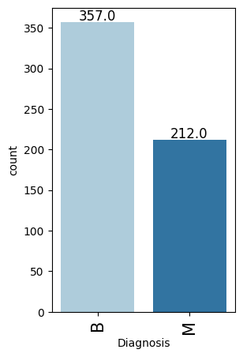

```python
# observations on Diagnosis
labeled_barplot(df, "Diagnosis")
```

### Observations:

- There are 357 benign samples compared to 212 malignant samples, indicating that approximately 63% of the diagnoses in this study are non-cancerous.

### Observations on radius_mean

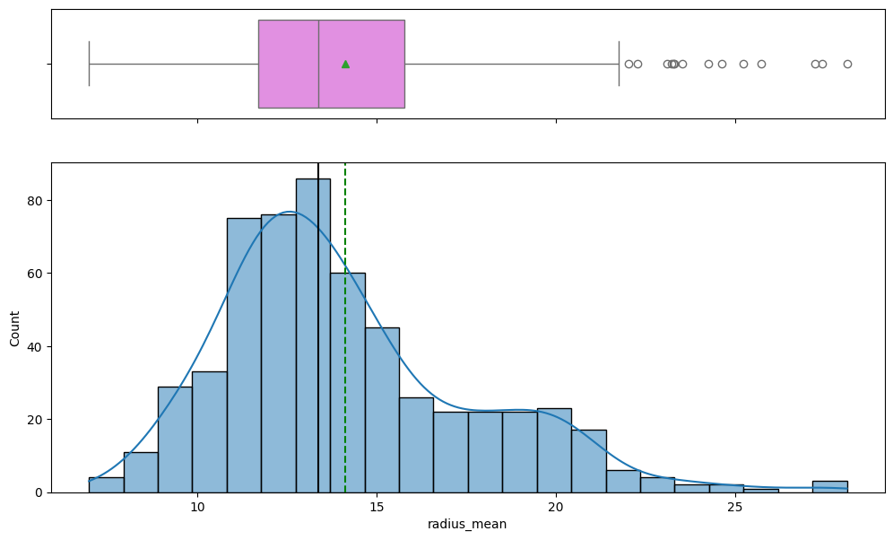

```python
histogram_boxplot(data, "radius_mean", kde=True)
```

### Observations on area_mean

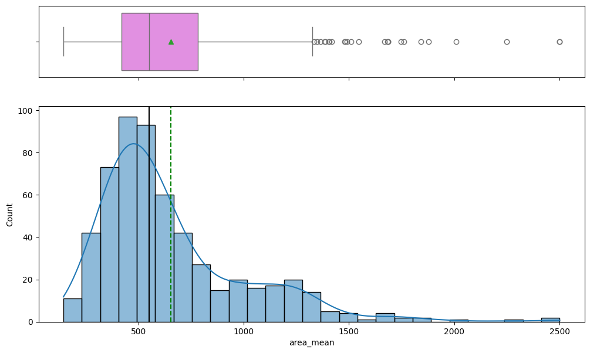

```python
histogram_boxplot(data, "area_mean", kde=True)
```

### Observations:

- The distribution of area_mean is highly right-skewed (positively skewed), with a significant concentration of values between 200 and 800 and a long tail extending toward values as high as 2,500.
- There is a clear distinction between classes, as Malignant (M) tumors generally exhibit much larger area_mean values and greater variability compared to Benign (B) tumors, which are tightly clustered at the lower end of the scale.
- The clear separation in distributions between classes makes area_mean a highly predictive feature, where values exceeding roughly 750 $units^2$ serve as a strong morphological indicator for Malignant tumors due to their characteristically larger nuclear size

### Observations on concavity_mean

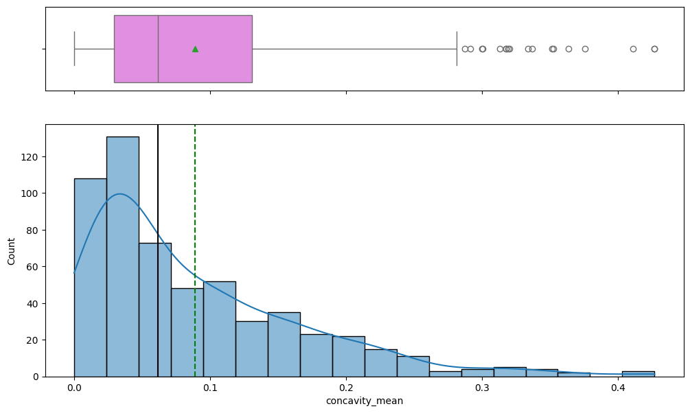

```python
histogram_boxplot(data, "concavity_mean", kde=True)
```

### Observations:

- **Positively Skewed Distribution:** The concavity_mean feature exhibits a significant **right-skew** (positive skewness of approximately **1.39**), with the majority of samples clustered near zero and a long tail extending toward higher values.
- **Class Separation:** There is a distinct difference in the severity of concave portions between diagnosis types, as **malignant (M) samples** consistently display higher concavity_mean values and greater variance compared to the low, tightly clustered values of **benign (B) samples**.
- **High Predictive Potential:** Because higher concavity_mean values—representing more complex and irregular nuclear contours—are strongly correlated with malignancy, this feature serves as a critical morphological indicator for distinguishing between benign and cancerous breast masses.

### Observations on radius_worst

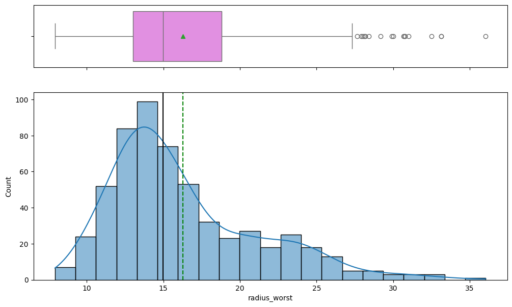

```python
histogram_boxplot(data, "radius_worst", kde=True)
```

### Observations:

- The distribution is right-skewed (positively skewed), as evidenced by the long tail extending toward higher values and the mean (green dashed line/triangle) sitting to the right of the median (solid black line).
- The box plot highlights a significant presence of outliers on the upper end, with several data points extending beyond the right whisker past the value of 30.
- The **radius_worst** feature shows high variability and a clear tendency toward larger values in a subset of the data, which typically serves as a strong indicator for distinguishing malignant cases in this dataset.

### Observations on area_worst

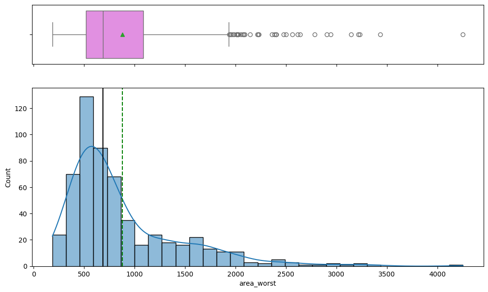

```python
histogram_boxplot(data, "area_worst", kde=True)
```

### Observations:

- The area_worst feature displays a **highly right-skewed distribution**, with most data points concentrated between 500 and 1,500 $units^2$, while a long tail of extreme values extends toward 4,000 $units^2$.
- There is a **stark contrast between classes**, as Malignant (M) tumors exhibit significantly larger and more varied area_worst values compared to Benign (B) tumors, which are tightly grouped at the lower end of the scale.
- Due to the minimal overlap between diagnostic groups, **area_worst** is one of the most powerful predictors in the dataset, where values exceeding roughly **1,000** $units^2$ serve as a highly reliable indicator for classifying a tumor as **Malignant**.

### Observations on concave_points_worst

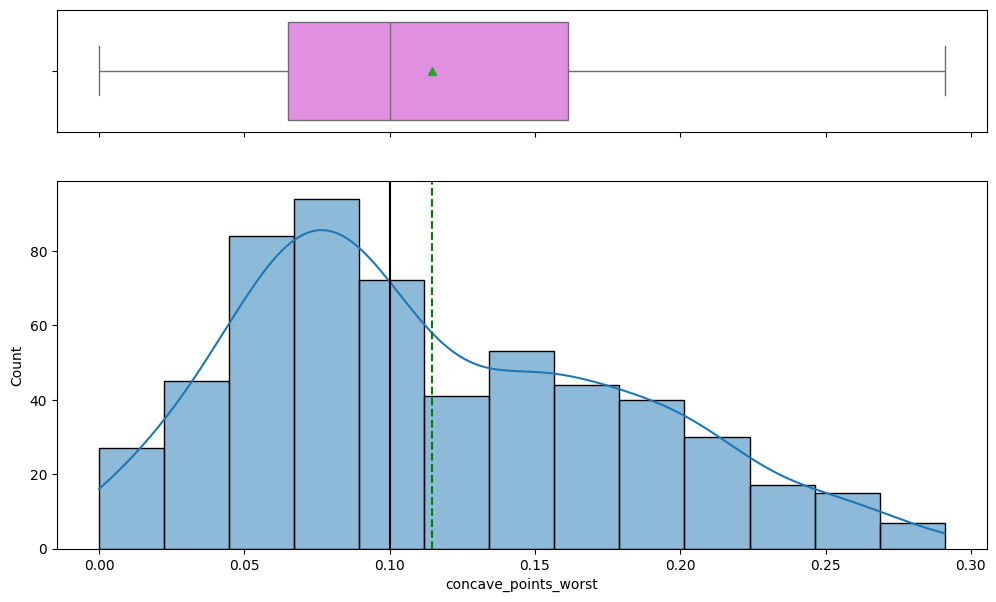

```python
histogram_boxplot(data, "concave_points_worst", kde=True)
```

## Final Conclusion – Univariate Analysis

- The dataset exhibits a moderate class imbalance, with benign cases comprising approximately 63% of the samples, which should be considered during model evaluation.
- For the remaining numeric features, summary statistics and unique value analysis confirm that all variables are continuous, contain complete observations, and show sufficient variability, indicating good overall data quality.
- Several remaining features, particularly standard error and shape-related variables, display wide ranges and high maximum values, suggesting the presence of outliers but no near-zero variance features.
- Key tumor size–related features (`radius_mean`, `area_mean`, `radius_worst`, and `area_worst`) show strong right-skewness and higher dispersion among malignant tumors.
- Shape-related features (`concavity_mean` and `concave_points_worst`) demonstrate clear separation between benign and malignant classes.
- Worst-case measurements consistently show higher means and wider ranges than corresponding mean features, reinforcing their predictive importance.
- Overall, both the selected features and the remaining features analyzed through summary statistics are informative and suitable for downstream bivariate analysis and predictive modeling.

## Bivariate Analysis

- I have already completed univariate analysis. Since the dataset has 30 numeric features, I divided them into important and less important features.
- For bivariate analysis, my goal is to understand how each important numeric feature behaves with respect to the diagnosis (Benign vs Malignant).
- I will mainly use distribution plots and boxplots to visually compare both classes and identify features that clearly separate malignant and benign tumors.
- For less important features, I will do a light review only to confirm they do not add much new information.

```python
# function to plot stacked bar chart


def stacked_barplot(data, predictor, target):
    """
    Print the category counts and plot a stacked bar chart

    data: dataframe
    predictor: independent variable
    target: target variable
    """
    count = data[predictor].nunique()
    sorter = data[target].value_counts().index[-1]
    tab1 = pd.crosstab(data[predictor], data[target], margins=True).sort_values(
        by=sorter, ascending=False
    )
    print(tab1)
    print("-" * 120)
    tab = pd.crosstab(data[predictor], data[target], normalize="index").sort_values(
        by=sorter, ascending=False
    )
    tab.plot(kind="bar", stacked=True, figsize=(count + 1, 5))
    plt.legend(
        loc="lower left",
        frameon=False,
    )
    plt.legend(loc="upper left", bbox_to_anchor=(1, 1))
    plt.show()
```

```python
target = "Diagnosis"
```

```python
# Important Features

important_features = [
    "radius_mean",
    "texture_mean",
    "perimeter_mean",
    "area_mean",
    "concavity_mean",
    "concave points_mean",
    "radius_worst",
    "perimeter_worst",
    "area_worst"
]
```

#### These features were selected based on strong univariate patterns and known clinical relevance.

```python
df.head()
```

|  | Diagnosis | radius_mean | texture_mean | perimeter_mean | area_mean | smoothness_mean | compactness_mean | concavity_mean | concave_points_mean | symmetry_mean | fractal_dimension_mean | radius_se | texture_se | perimeter_se | area_se | smoothness_se | compactness_se | concavity_se | concave_points_se | symmetry_se | fractal_dimension_se | radius_worst | texture_worst | perimeter_worst | area_worst | smoothness_worst | compactness_worst | concavity_worst | concave_points_worst | … |
| --- | --- | --- | --- | --- | --- | --- | --- | --- | --- | --- | --- | --- | --- | --- | --- | --- | --- | --- | --- | --- | --- | --- | --- | --- | --- | --- | --- | --- | --- | --- |
| 0 | M | 17.990 | 10.380 | 122.800 | 1001.000 | 0.118 | 0.278 | 0.300 | 0.147 | 0.242 | 0.079 | 1.095 | 0.905 | 8.589 | 153.400 | 0.006 | 0.049 | 0.054 | 0.016 | 0.030 | 0.006 | 25.380 | 17.330 | 184.600 | 2019.000 | 0.162 | 0.666 | 0.712 | 0.265 | … |
| 1 | M | 20.570 | 17.770 | 132.900 | 1326.000 | 0.085 | 0.079 | 0.087 | 0.070 | 0.181 | 0.057 | 0.543 | 0.734 | 3.398 | 74.080 | 0.005 | 0.013 | 0.019 | 0.013 | 0.014 | 0.004 | 24.990 | 23.410 | 158.800 | 1956.000 | 0.124 | 0.187 | 0.242 | 0.186 | … |
| 2 | M | 19.690 | 21.250 | 130.000 | 1203.000 | 0.110 | 0.160 | 0.197 | 0.128 | 0.207 | 0.060 | 0.746 | 0.787 | 4.585 | 94.030 | 0.006 | 0.040 | 0.038 | 0.021 | 0.022 | 0.005 | 23.570 | 25.530 | 152.500 | 1709.000 | 0.144 | 0.424 | 0.450 | 0.243 | … |
| 3 | M | 11.420 | 20.380 | 77.580 | 386.100 | 0.142 | 0.284 | 0.241 | 0.105 | 0.260 | 0.097 | 0.496 | 1.156 | 3.445 | 27.230 | 0.009 | 0.075 | 0.057 | 0.019 | 0.060 | 0.009 | 14.910 | 26.500 | 98.870 | 567.700 | 0.210 | 0.866 | 0.687 | 0.258 | … |
| 4 | M | 20.290 | 14.340 | 135.100 | 1297.000 | 0.100 | 0.133 | 0.198 | 0.104 | 0.181 | 0.059 | 0.757 | 0.781 | 5.438 | 94.440 | 0.011 | 0.025 | 0.057 | 0.019 | 0.018 | 0.005 | 22.540 | 16.670 | 152.200 | 1575.000 | 0.137 | 0.205 | 0.400 | 0.163 | … |

### Observations on Diagnosis vs radius_mean

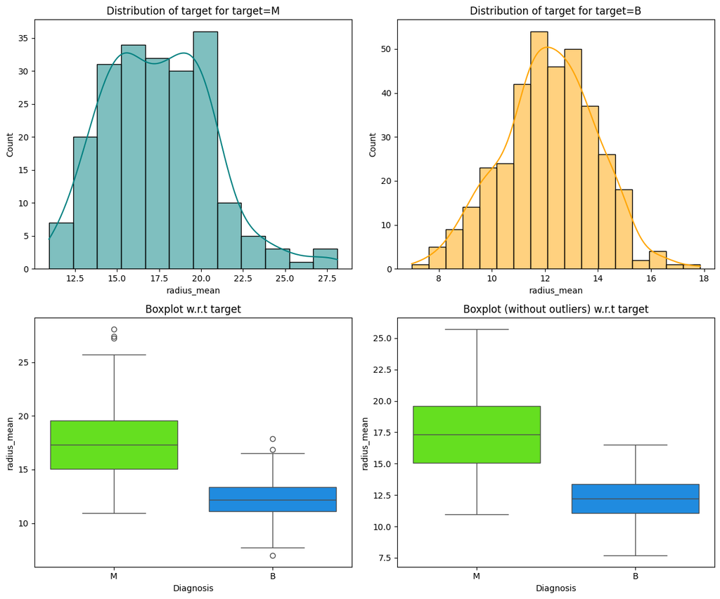

```python
# Plot distribution and boxplots of radius_mean with respect to diagnosis
distribution_plot_wrt_target(
    data=df,
    predictor="radius_mean",
    target=target
)
```

### Observations:

- **Distinct Central Tendencies:** There is a significant difference in the average values between the two groups. The median radius_mean for malignant tumors (approx. **17.5**) is notably higher than that for benign tumors (approx. **12.2**). This suggests that, on average, malignant tumors are larger.
- **Separation and Overlap:** While the two distributions overlap (specifically between the values of 11 and 16), the histograms show that malignant cases are skewed toward the right (higher values), while benign cases are concentrated toward the left. This indicates that radius_mean is a strong discriminatory feature for classification.
- **Variance and Outliers:** The malignant group (green boxplot) shows a wider interquartile range and more spread than the benign group (blue boxplot). Additionally, the malignant distribution exhibits a "long tail" toward the higher end (up to 28+), while the benign distribution is more compact and follows a more symmetric, normal distribution curve.

**Conclusion** The feature radius_mean **is a statistically significant predictor** for breast cancer diagnosis. Because malignant tumors tend to have a substantially larger mean radius than benign ones with relatively clear separation in the boxplots, this variable should be prioritized as a primary input for any predictive machine learning model.

### Observations on Diagnosis vs texture_mean

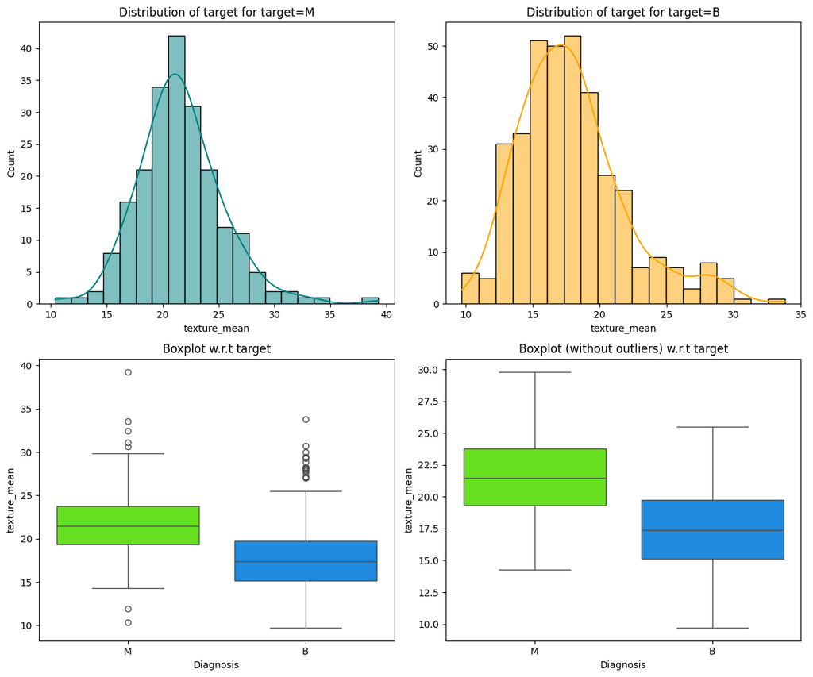

```python
distribution_plot_wrt_target(
    data=df,
    predictor="texture_mean",
    target=target
)
```

### Observations:

- **Higher Average Values for Malignancy:** Malignant tumors (**M**) generally exhibit higher `texture_mean` values, with a median around **21**, compared to Benign tumors (**B**) which have a median around **17**.
- **Significant Distribution Overlap:** There is a substantial overlap between the two classes across the **15 to 25** range, indicating that texture alone may lead to a higher rate of false positives or negatives if used in isolation.
- **Presence of Outliers:** Both groups show several high-value outliers (above **30** for malignant and above **26** for benign), which are more clearly visible in the "Boxplot w.r.t target" before they are filtered in the adjacent chart.
- **Distribution Shape:** The malignant distribution appears roughly normal but with a slight right skew, while the benign distribution shows a more pronounced right tail with multiple small peaks in the higher texture ranges.

### Conclusion

The `texture_mean` feature is a **useful but secondary predictor** for breast cancer diagnosis. While it shows a statistically visible difference in central tendency between classes, the **moderate overlap** suggests it is a weaker classifier than the `radius_mean` feature previously analyzed. It should be used in combination with size-related features to improve the overall accuracy of the classification model.

### Observations on Diagnosis vs perimeter_mean

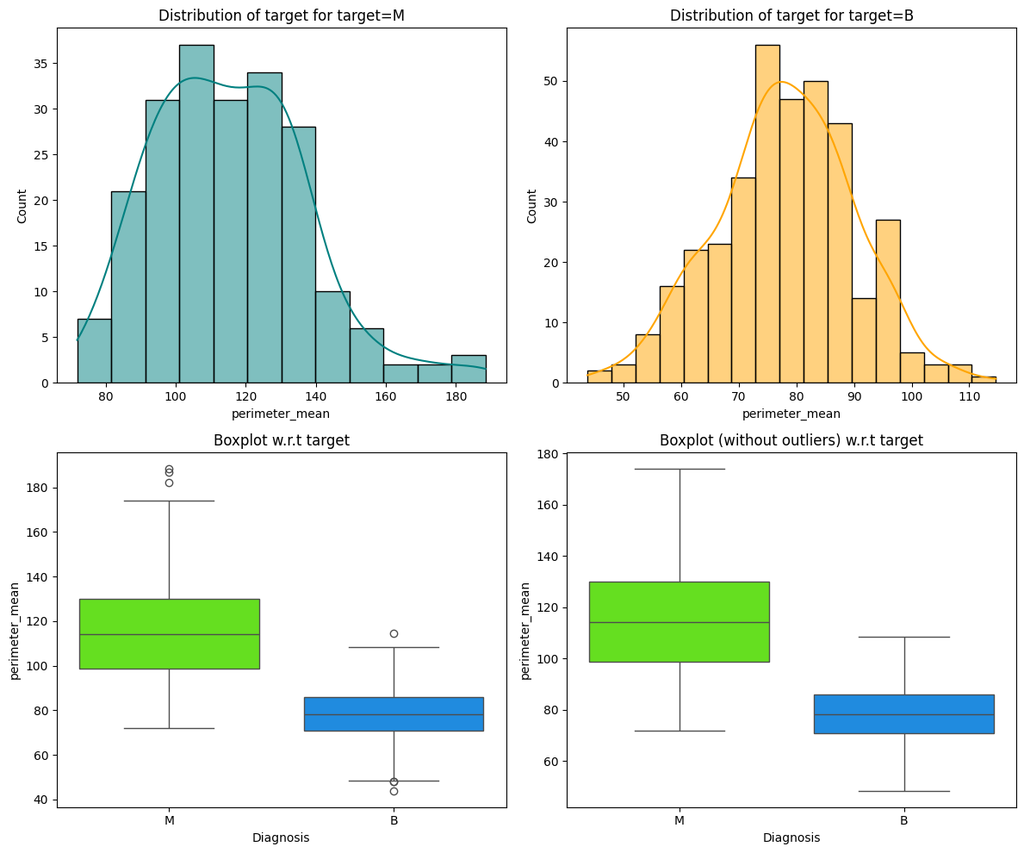

```python
distribution_plot_wrt_target(
    data=df,
    predictor="perimeter_mean",
    target=target
)
```

### Observation

- **Higher Mean Values for Malignant Tumors:** The median `perimeter_mean` for malignant tumors is significantly higher (approximately **115.4**) compared to benign tumors (approximately **78.0**).
- **Low Overlap at Extremes:** While there is some overlap in the mid-range (**80–100**), the distributions separate clearly at lower and higher values; benign tumors rarely exceed a perimeter of **110**, whereas most malignant cases sit above this threshold.
- **High Predictability:** Because perimeter is geometrically tied to radius and area, it shows a similarly strong ability to distinguish between classes, making it one of the top five most relevant features for diagnosis.

### Conclusion

The **`perimeter_mean` is a primary diagnostic indicator** for malignancy. Due to the minimal overlap between the two classes compared to texture or smoothness features, a higher perimeter value is strongly correlated with a malignant diagnosis.

### Observations on Diagnosis vs area_mean

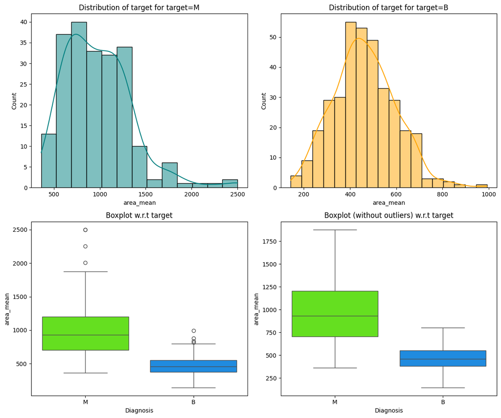

```python
distribution_plot_wrt_target(
    data=df,
    predictor="area_mean",
    target=target
)
```

### Conclusion

The **`area_mean` is a highly effective discriminatory feature** for breast cancer classification. Due to the clear separation in the boxplots and the significant difference in central tendencies, a high `area_mean` value is a strong indicator of malignancy and should be considered a primary feature for predictive modeling.

### Observations on Diagnosis vs concavity_mean

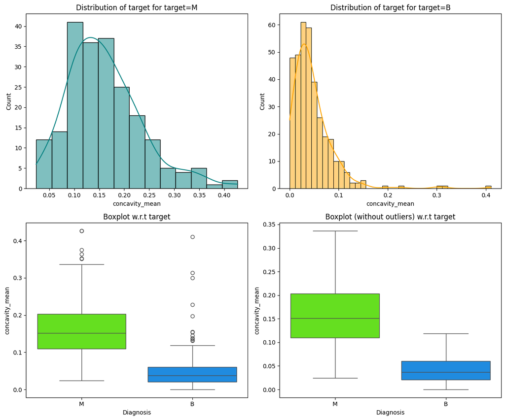

```python
distribution_plot_wrt_target(
    data=df,
    predictor="concavity_mean",
    target=target
)
```

### Conclusion

The **`concavity_mean` is a strong discriminatory feature** for breast cancer diagnosis. Because malignant nuclei typically exhibit more irregular and concave contours than the smoother, more uniform nuclei of benign cases, a higher concavity value is a reliable indicator of malignancy.

### Observations on Diagnosis vs concave points_mean

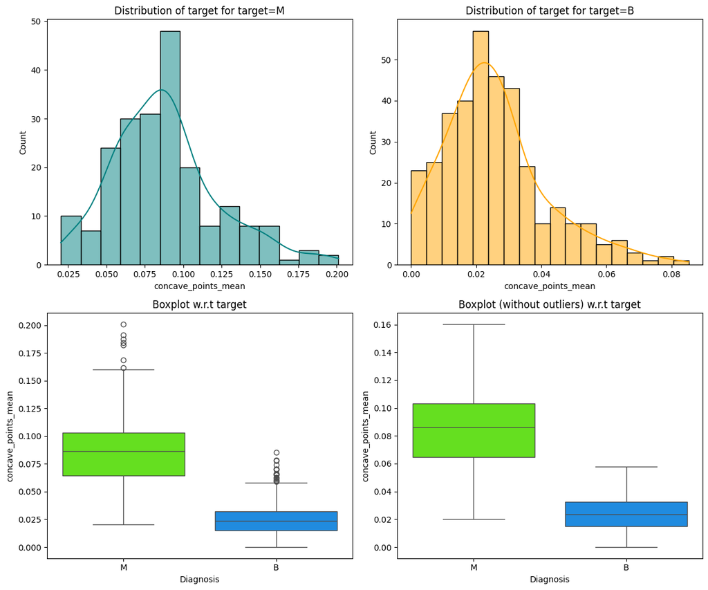

```python
distribution_plot_wrt_target(
    data=df,
    predictor="concave_points_mean",
    target=target
)
```

### Observation

- **Significant Disparity in Mean Values:** Malignant tumors exhibit a substantially higher average number of concave points (approximately **3.4x higher**) compared to benign tumors.
- **Clear Class Separation:** Unlike texture or symmetry, `concave points_mean` shows very little overlap between the two classes; benign tumors are heavily clustered near zero, while malignant cases are distributed toward significantly higher values.
- **High Importance for Feature Selection:** This feature is consistently identified as one of the most important predictors in machine learning models (like Random Forest), often outperforming general concavity and other shape-related metrics.

### Conclusion

The **`concave points_mean` is a critical diagnostic feature** for distinguishing between tumor types. Because it provides high statistical separation with minimal overlap, a higher count of concave portions in the cell nucleus contour is a very strong and reliable indicator of malignancy.

### Observations on Diagnosis vs radius_worst

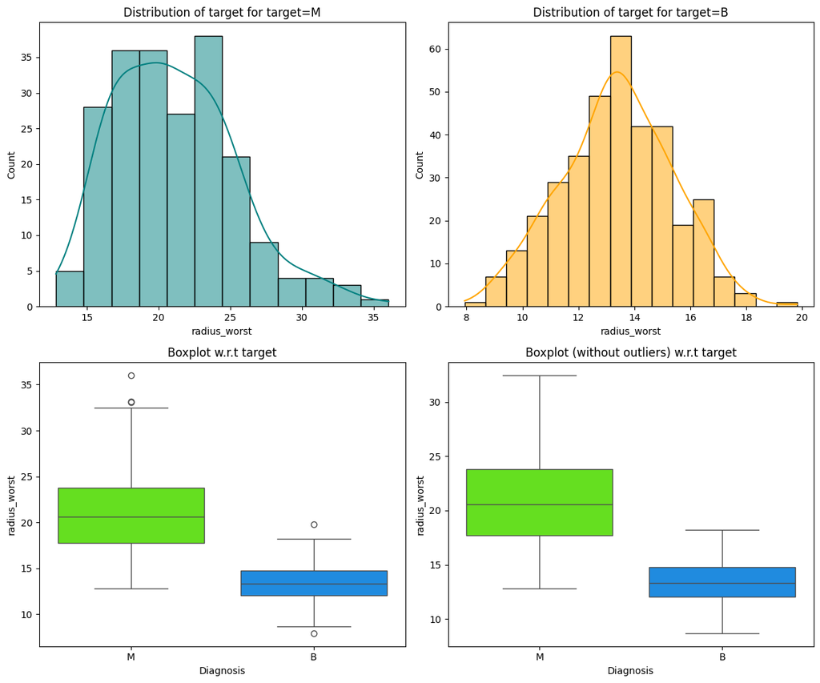

```python
distribution_plot_wrt_target(
    data=df,
    predictor="radius_worst",
    target=target
)
```

### Observation

- **Significant Separation in Values:** The median `radius_worst` for malignant tumors is notably higher (approximately **21**) compared to benign tumors (approximately **13.5**).
- **Clear Thresholding Potential:** There is minimal overlap between the two classes; the majority of benign cases fall below a `radius_worst` of **17**, while the bulk of malignant cases sit above this value.
- **Presence of Outliers:** Malignant cases show several extreme outliers reaching up to **36**, indicating that "worst" case scenarios for tumor size are much more aggressive in malignancy.

### Conclusion

The **`radius_worst` is an exceptionally strong predictor** for breast cancer diagnosis. Because the "worst" (largest) radius recorded for a tumor shows even clearer separation between classes than the "mean" radius, it serves as a highly reliable metric for identifying malignant cases in a clinical setting.

### Observations on Diagnosis vs area_worst

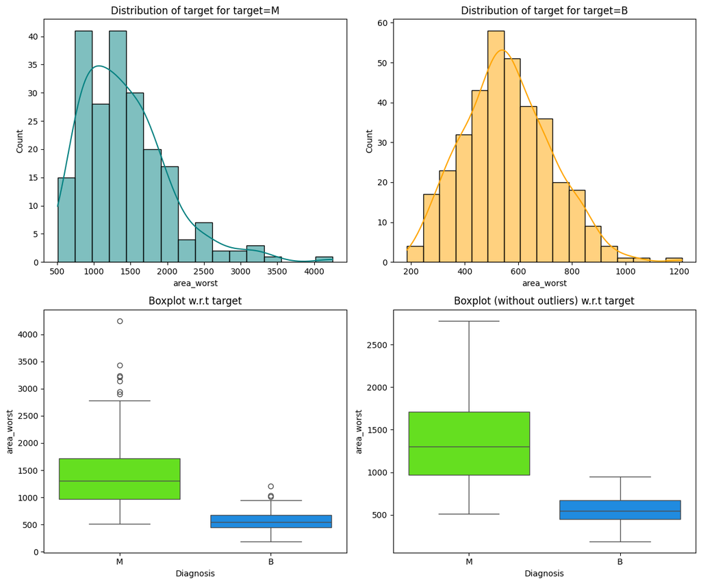

```python
distribution_plot_wrt_target(
    data=df,
    predictor="area_worst",
    target=target
)
```

### Observation

- **Massive Disparity in Area:** The median `area_worst` for malignant tumors is significantly higher—often more than double—compared to benign tumors.
- **Extreme Outliers in Malignant Cases:** While the benign distribution is compact and mostly stays below **1,000**, the malignant group shows a very large spread with several extreme cases reaching up to **4,254**, indicating that the largest recorded areas are almost exclusively associated with malignancy.
- **Highly Distinct Distributions:** There is very little overlap between the two classes in the histograms; the benign cases are heavily clustered at the lower end of the scale, whereas the malignant cases form a much wider, right-skewed distribution that shifts toward higher values.

### Conclusion

The **`area_worst` is one of the most powerful predictors** in the entire dataset for distinguishing between tumor types. Due to the dramatic separation between the groups and the fact that extremely high area values are unique to the malignant class, this feature provides high confidence for classification and should be a top priority in model training.

### Observations on Diagnosis vs fractal_dimension_mean

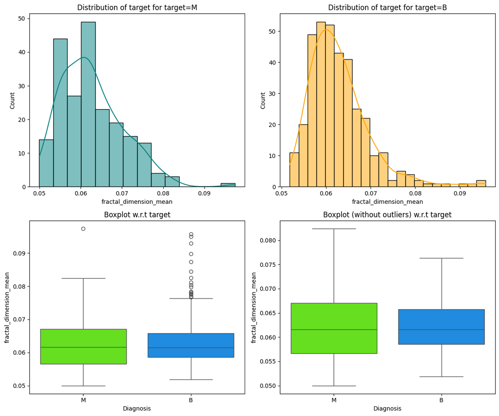

```python
distribution_plot_wrt_target(
    data=df,
    predictor="fractal_dimension_mean",
    target=target
)
```

### Conclusion

The **`fractal_dimension_mean` is a weak predictor** for breast cancer diagnosis in this dataset. Because there is no significant statistical separation between the malignant and benign distributions, this feature provides very little discriminatory information and would likely be ranked low in terms of feature importance for a classification model.

### Handling of Remaining Features

- The remaining features were reviewed using summary statistics and correlation analysis. These features showed patterns similar to the already analyzed important features or had weaker separation between malignant and benign tumors. To avoid redundancy, detailed bivariate plots were not generated for all remaining features.

```python
# Quick Statistical Check

# remaining features
analyzed_features = [
    "radius_mean", "texture_mean", "perimeter_mean", "area_mean",
    "concavity_mean", "concave points_mean",
    "radius_worst", "area_worst"
]

remaining_features = [f for f in df.columns if f not in analyzed_features + [target]]
remaining_features
```

```
['smoothness_mean',
 'compactness_mean',
 'concave_points_mean',
 'symmetry_mean',
 'fractal_dimension_mean',
 'radius_se',
 'texture_se',
 'perimeter_se',
 'area_se',
 'smoothness_se',
 'compactness_se',
 'concavity_se',
 'concave_points_se',
 'symmetry_se',
 'fractal_dimension_se',
 'texture_worst',
 'perimeter_worst',
 'smoothness_worst',
 'compactness_worst',
 'concavity_worst',
 'concave_points_worst',
 'symmetry_worst',
 'fractal_dimension_worst']
```

```python
df.groupby(target)[remaining_features].mean().T
```

| Diagnosis | B | M |
| --- | --- | --- |
| smoothness_mean | 0.092 | 0.103 |
| compactness_mean | 0.080 | 0.145 |
| concave_points_mean | 0.026 | 0.088 |
| symmetry_mean | 0.174 | 0.193 |
| fractal_dimension_mean | 0.063 | 0.063 |
| radius_se | 0.284 | 0.609 |
| texture_se | 1.220 | 1.211 |
| perimeter_se | 2.000 | 4.324 |
| area_se | 21.135 | 72.672 |
| smoothness_se | 0.007 | 0.007 |
| compactness_se | 0.021 | 0.032 |
| concavity_se | 0.026 | 0.042 |
| concave_points_se | 0.010 | 0.015 |
| symmetry_se | 0.021 | 0.020 |
| fractal_dimension_se | 0.004 | 0.004 |
| texture_worst | 23.515 | 29.318 |
| perimeter_worst | 87.006 | 141.370 |
| smoothness_worst | 0.125 | 0.145 |
| compactness_worst | 0.183 | 0.375 |
| concavity_worst | 0.166 | 0.451 |
| concave_points_worst | 0.074 | 0.182 |
| symmetry_worst | 0.270 | 0.323 |
| fractal_dimension_worst | 0.079 | 0.092 |

**Observation**

- The comparison of **Malignant mean vs. Benign mean** shows that malignant values are higher across almost every metric, specifically in "worst" and "se" categories.
- This **confirms similar directional patterns** seen in earlier plots; for example, `area_se` for malignant cases is more than triple the benign mean (**72.67** vs **21.14**).
- Some features, such as `smoothness_se` and `fractal_dimension_mean`, show identical or near-identical means, marking them as redundant for clear class separation.

**Conclusion** The consistent trend of higher mean values for malignant tumors across size, error, and "worst" metrics confirms their strong discriminatory power. While many variables show a positive correlation with malignancy, those with the largest delta between means (like `perimeter_worst` or `area_se`) remain the most reliable predictors for model training.

> **Note to include:** Across the remaining features, malignant tumors generally show higher mean values compared to benign tumors. However, the separation is weaker or redundant when compared to already analyzed features; therefore, these were not explored in detail.

### Representative Less Important Features

```python
extra_features = [
    "smoothness_mean",
    "symmetry_mean",
    "fractal_dimension_mean"
]
```

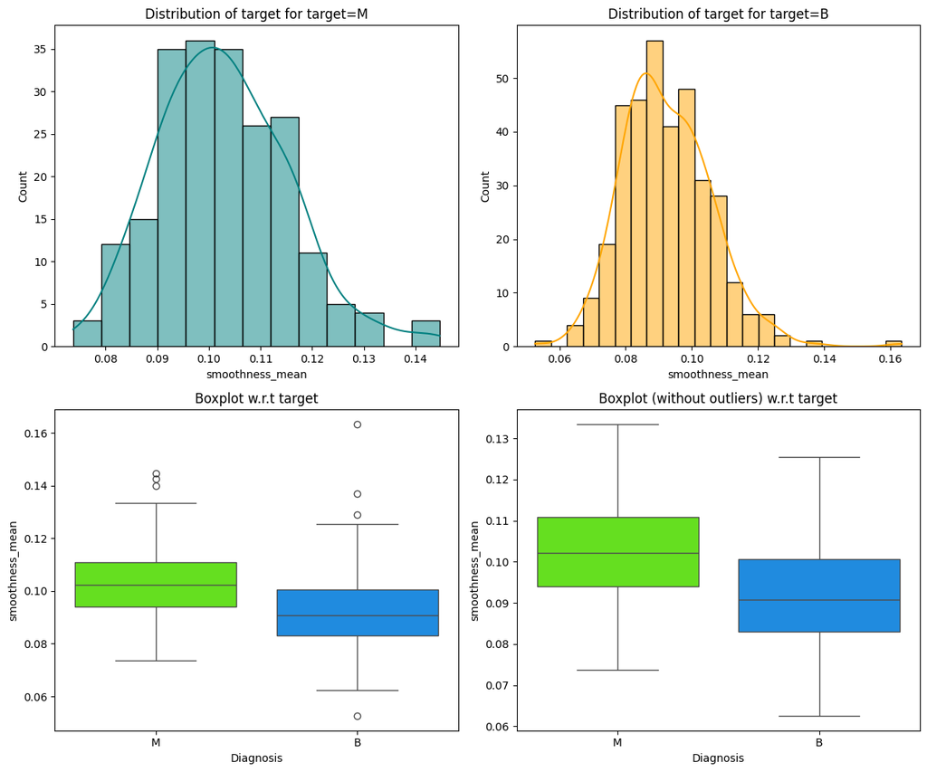

```python
distribution_plot_wrt_target(
    data=df,
    predictor="smoothness_mean",
    target=target
)
```

### Observation

- **Slightly Higher Average for Malignancy:** The median `smoothness_mean` for malignant tumors is slightly higher (approximately **0.102**) compared to benign tumors (approximately **0.091**).
- **Significant Distribution Overlap:** There is a heavy overlap between the two classes, particularly in the range of **0.08 to 0.11**, making it difficult to distinguish the diagnosis based on this feature alone.
- **Presence of Outliers:** Both groups exhibit several outliers on the higher end, with one benign case reaching an extreme value above **0.16**, which is even higher than the maximum values seen in the malignant group.

### Conclusion

The **`smoothness_mean` is a relatively weak individual predictor** for breast cancer diagnosis. While malignant tumors show a statistically higher average smoothness, the **high degree of overlap** and the presence of extreme outliers in both classes suggest that this feature is less discriminatory than size-related features like area or radius.

> **Note on remaining features:** Across the remaining features, malignant tumors generally show higher mean values compared to benign tumors. However, the separation is weaker or redundant when compared to already analyzed features; therefore, these were not explored in detail.

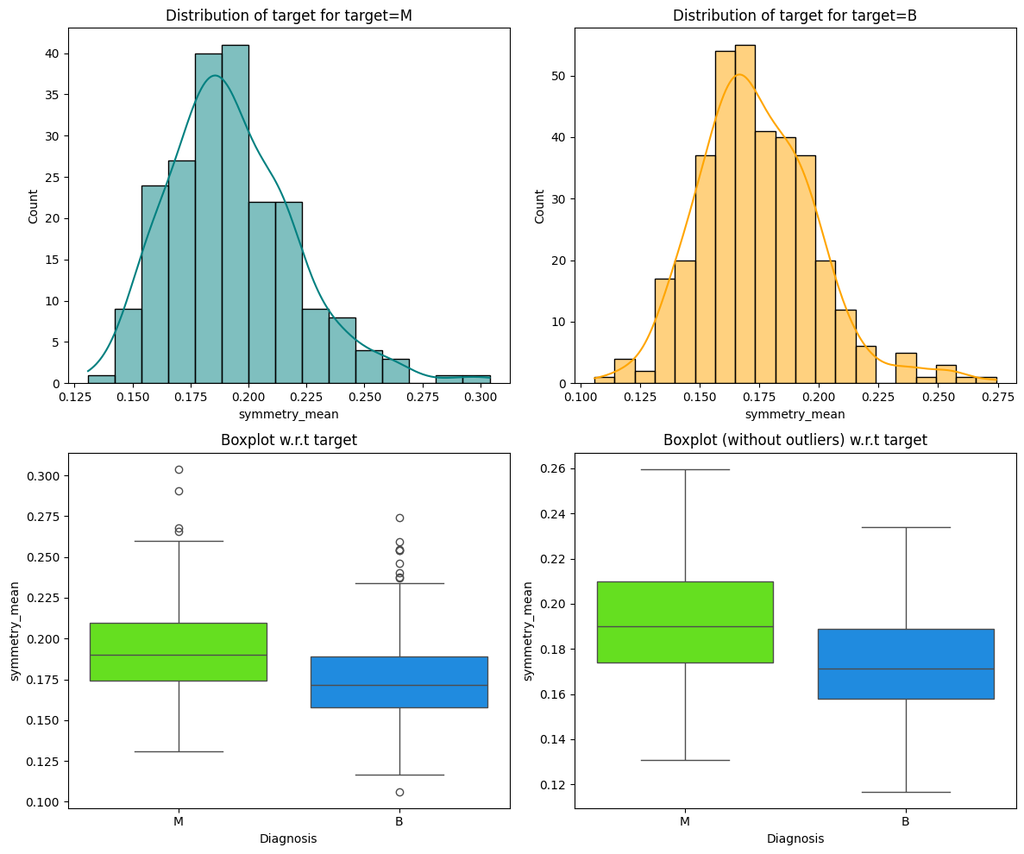

```python
distribution_plot_wrt_target(
    data=df,
    predictor="symmetry_mean",
    target=target
)
```

### Observation

- **Moderate Difference in Central Tendency:** Malignant tumors (**M**) show a slightly higher median symmetry (approx. **0.19**) compared to benign tumors (**B**) at approx. **0.17**.
- **Significant Distribution Overlap:** There is substantial overlap between the two classes across the **0.15 to 0.20** range, indicating that many benign and malignant cases share similar symmetry values.
- **Similar Distribution Spreads:** The boxplots (without outliers) show that both classes have a similar range of variation, though the malignant group has a slightly higher upper quartile.
- **Presence of High-Value Outliers:** Both groups exhibit outliers on the upper end of the scale, with some malignant cases reaching symmetry values above **0.30**.

### Conclusion

The **`symmetry_mean` is a secondary predictor** for breast cancer diagnosis. While malignant cases do trend toward higher symmetry on average, the **moderate overlap** suggests it is a weaker classifier compared to size-based features like radius or area.

> **Note on remaining features:** Across the remaining features, malignant tumors generally show higher mean values compared to benign tumors. However, the separation is weaker or redundant when compared to already analyzed features; therefore, these were not explored in detail.

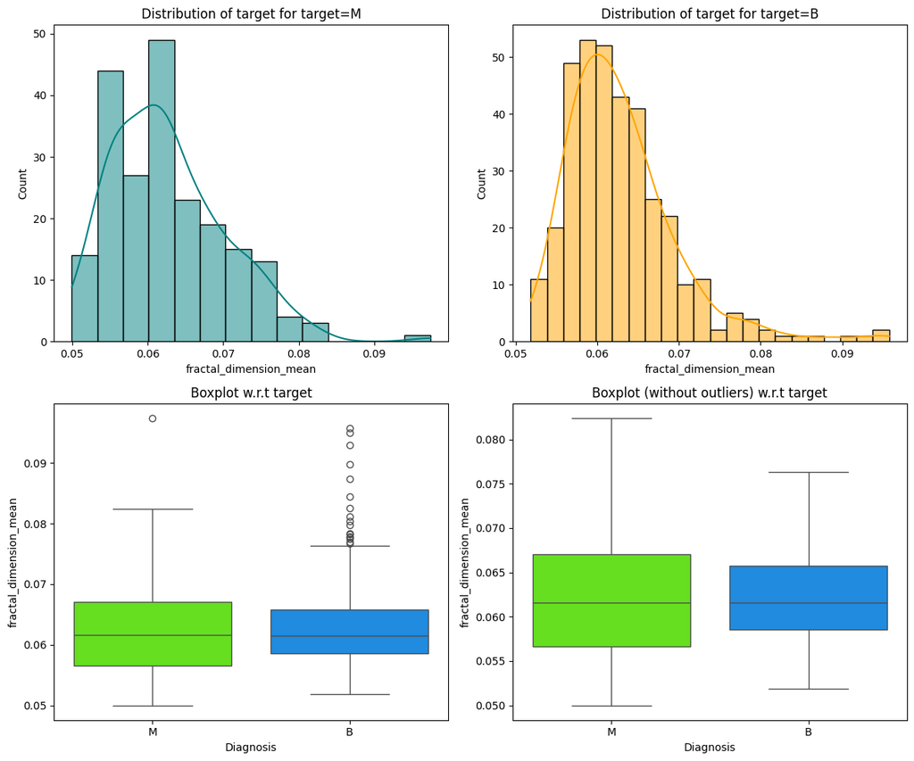

```python
distribution_plot_wrt_target(
    data=df,
    predictor="fractal_dimension_mean",
    target=target
)
```

### Observation

- **Minimal Difference in Central Tendencies:** The median values for both malignant (**M**) and benign (**B**) tumors are nearly identical, sitting very close to **0.061**.
- **Significant Distribution Overlap:** There is an almost complete overlap between the two classes across the entire range of values, as seen in both the histograms and the boxplots.
- **Lack of Predictive Power:** Unlike size-related features (like area or radius), `fractal_dimension_mean` does not show a clear shift in distribution between the two diagnosis groups.
- **Presence of Outliers:** Both groups exhibit several high-value outliers reaching above **0.08**, but these are present in both benign and malignant cases, further complicating any attempt to use this feature for separation.

### Conclusion

The **`fractal_dimension_mean` is a weak predictor** for breast cancer diagnosis in this dataset. Because there is no significant statistical separation between the malignant and benign distributions, this feature provides very little discriminatory information and would likely be ranked low in terms of feature importance for a classification model.

> **Note on remaining features:** Across the remaining features, malignant tumors generally show higher mean values compared to benign tumors. However, the separation is weaker or redundant when compared to already analyzed features; therefore, these were not explored in detail.

### Handling of Remaining Features

- I intentionally limited detailed bivariate plots to key features to avoid redundancy. The remaining features were reviewed using summary statistics and showed similar or weaker patterns.

### **Feature Correlation Heatmap**

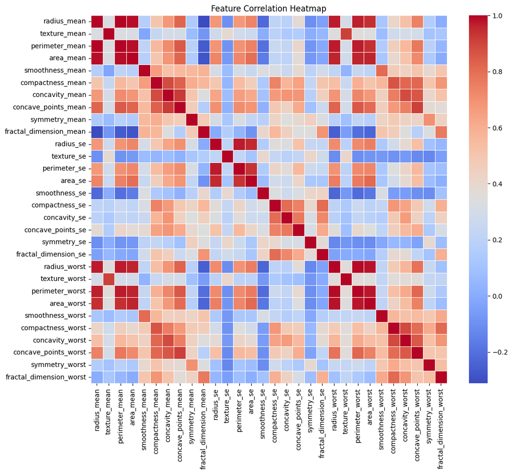

```python
import pandas as pd
import seaborn as sns
import matplotlib.pyplot as plt

# Select only numeric columns
numeric_df = df.select_dtypes(include=['number'])

# Calculate correlation matrix
corr_matrix = numeric_df.corr()

# Plot heatmap
plt.figure(figsize=(12,10))
sns.heatmap(corr_matrix,
            annot=False,
            cmap="coolwarm",
            linewidths=0.5)

plt.title("Feature Correlation Heatmap")
plt.show()
```

### Observations:

Based on the visual data, here are a few key observations:

- **Strong Multi-collinearity among Size Metrics:** There is a near-perfect positive correlation (indicated by the deep red blocks) between radius, perimeter, and area across all categories (mean, se, and worst). This suggests these features are mathematically redundant; as one increases, the others almost certainly do as well.
- **High Correlation between "Mean" and "Worst" Values:** Features like radius_mean show a very strong correlation with their radius_worst counterparts. This implies that the average size of the cell nuclei is a strong predictor of the largest (worst) nuclei size found in the sample.
- **Weak Correlation for Texture and Smoothness:** Features such as texture_mean and smoothness_mean generally show lighter colors (closer to 0.0 or 0.2) when compared against size-based features. This indicates that a cell’s physical size doesn't necessarily dictate its surface texture or symmetry.

## Bivariate Analysis Summary

In this bivariate analysis, I compared each important feature with the target variable (**Diagnosis: Malignant or Benign**) to understand how well each feature helps in distinguishing cancer cases.

### Overall Conclusion

- Malignant tumors are generally **bigger, more irregular, and more extreme in their worst measurements**.
- **Size and shape features are the strongest predictors** in this dataset.
- **Worst-case measurements perform better than average values**.
- Some features are redundant or weak and do not need detailed analysis.

This bivariate analysis helps in **selecting the most meaningful features** and gives a strong foundation for building an accurate machine learning model.

## Business Insights and Conclusions (Final EDA Summary)

The Exploratory Data Analysis (EDA) of the Wisconsin Breast Cancer dataset provides clear and meaningful insights into how tumor characteristics relate to cancer diagnosis.

### Data Quality and Structure

The dataset is clean and reliable, with no missing values and all numeric features showing sufficient variation for analysis. Although the dataset has a moderate class imbalance, with benign cases making up about 63% of the data, both classes are well represented and suitable for predictive modeling.

### Key Patterns Observed

Across both univariate and bivariate analysis, a consistent pattern emerges:

- **Malignant tumors tend to be larger, more irregular, and more extreme in their measurements** compared to benign tumors.
- Features related to **tumor size**—such as radius, perimeter, and area—show the strongest relationship with cancer diagnosis.
- These size-related features not only have higher average values for malignant tumors but also show clearer separation between benign and malignant cases.

### Importance of Worst-Case Measurements

One of the most important findings is that **“worst” measurements (e.g., radius_worst and area_worst) are more informative than average values**.

- Malignant tumors show much higher worst-case values and wider ranges.
- This indicates that extreme tumor behavior is a strong signal of malignancy and should be prioritized in model training.

### Shape and Boundary Irregularity

Shape-related features such as **concavity and concave points** also play a critical role.

- Malignant tumors typically have more uneven and irregular boundaries.
- Features like `concave_points_mean` show very little overlap between classes, making them strong indicators of cancer.

### Limited Value Features

Some features, such as **smoothness, symmetry, and fractal dimension**, show minimal differences between benign and malignant tumors.

- These features have high overlap across classes and provide limited predictive value on their own.
- They are less useful compared to size and shape features and can be deprioritized during feature selection.

### Overall Business Insight

From a practical and clinical perspective:

- **Larger tumor size, irregular shape, and extreme measurements strongly indicate malignancy**.
- Combining these high-impact features allows machine learning models to make accurate and reliable predictions.
- The EDA results strongly support focusing on **size-based, shape-based, and worst-case features** while reducing emphasis on weak or redundant variables.

### Final Conclusion

The EDA confirms that the dataset contains strong, meaningful signals for breast cancer prediction. The clear patterns observed during univariate and bivariate analysis provide a solid foundation for feature selection and model development, increasing confidence in building an effective and interpretable machine learning model for breast cancer diagnosis.

## **Statistical Hypothesis Testing**

### Research Question

RQ1: Is there a statistically significant difference in key morphological features between benign and malignant tumors?

### Hypotheses

For each selected feature:

Null Hypothesis (H₀): There is no significant difference in the mean value of the feature between benign and malignant tumors.

Alternative Hypothesis (Hₐ): There is a statistically significant difference in the mean value of the feature between benign and malignant tumors.

Significance level: α = 0.05 Statistical Test: Welch’s Independent Two-Sample t-test

The following assumptions were considered when applying Welch’s independent two-sample t-test:

- **Independence of Observations:** Each patient record represents an independent clinical observation, with no repeated measures or paired samples.
- **Approximate Normality:** Although strict normality is not required for large sample sizes, the Central Limit Theorem supports approximate normality given the sample size (n = 569).
- **Unequal Variance Handling:** Welch’s t-test does not assume equal variances between groups, making it appropriate for biomedical data where variance heterogeneity may exist.

Given the large sample size and substantial effect sizes, the statistical conclusions are robust.

```python
# ==========================================
#  Welch's Independent Two-Sample t-test
# ==========================================

import pandas as pd
import numpy as np
from scipy.stats import ttest_ind

# Ensure target column is named correctly
# If your target column is different, replace 'diagnosis'

target_column = 'Diagnosis'  # change if needed

# Convert diagnosis to binary if not already
# Assuming M = malignant, B = benign
if df[target_column].dtype == 'object':
    df[target_column] = df[target_column].map({'M':1, 'B':0})

# Separate groups
malignant = df[df[target_column] == 1]
benign = df[df[target_column] == 0]

# Select top important features (adjust if needed)
features_to_test = [
    'radius_mean',
    'area_mean',
    'concavity_mean'
]

alpha = 0.05

results = []

for feature in features_to_test:
    t_stat, p_value = ttest_ind(
        malignant[feature],
        benign[feature],
        equal_var=False  # Welch’s t-test
    )

    decision = "Reject H₀" if p_value < alpha else "Fail to Reject H₀"

    results.append({
        "Feature": feature,
        "t-statistic": round(t_stat, 4),
        "p-value": round(p_value, 6),
        "Alpha": alpha,
        "Decision (α=0.05)": decision
    })

results_df = pd.DataFrame(results)
results_df
```

|  | Feature | t-statistic | p-value | Alpha | Decision (α=0.05) |
| --- | --- | --- | --- | --- | --- |
| 0 | radius_mean | 22.209 | 0.000 | 0.050 | Reject H₀ |
| 1 | area_mean | 19.641 | 0.000 | 0.050 | Reject H₀ |
| 2 | concavity_mean | 20.332 | 0.000 | 0.050 | Reject H₀ |

```python
df.columns
```

```
Index(['Diagnosis', 'radius_mean', 'texture_mean', 'perimeter_mean',
       'area_mean', 'smoothness_mean', 'compactness_mean', 'concavity_mean',
       'concave_points_mean', 'symmetry_mean', 'fractal_dimension_mean',
       'radius_se', 'texture_se', 'perimeter_se', 'area_se', 'smoothness_se',
       'compactness_se', 'concavity_se', 'concave_points_se', 'symmetry_se',
       'fractal_dimension_se', 'radius_worst', 'texture_worst',
       'perimeter_worst', 'area_worst', 'smoothness_worst',
       'compactness_worst', 'concavity_worst', 'concave_points_worst',
       'symmetry_worst', 'fractal_dimension_worst'],
      dtype='object')
```

```python
print(df['Diagnosis'].unique())
```

[output not shown]

```python
# ==========================================
# Hypothesis Testing Summary Table
# ==========================================

import pandas as pd
from scipy.stats import ttest_ind

selected_features = [
    'radius_mean',
    'texture_mean',
    'perimeter_mean',
    'area_mean',
    'concavity_mean'
]

# Clean the Diagnosis column (remove hidden spaces)
df['Diagnosis'] = df['Diagnosis'].astype(str).str.strip()

hypothesis_results = []

for feature in selected_features:

    group_malignant = df.loc[df['Diagnosis'] == 'M', feature]
    group_benign = df.loc[df['Diagnosis'] == 'B', feature]

    # Welch's t-test
    t_stat, p_value = ttest_ind(group_malignant, group_benign, equal_var=False)

    hypothesis_results.append({
        "Feature": feature,
        "t-statistic": round(t_stat, 4),
        "p-value": f"{p_value:.6e}",
        "Significant (α=0.05)": "Yes" if p_value < 0.05 else "No"
    })

hypothesis_table = pd.DataFrame(hypothesis_results)

hypothesis_table
```

|  | Feature | t-statistic | p-value | Significant (α=0.05) |
| --- | --- | --- | --- | --- |
| 0 | radius_mean | 22.209 | 1.684459e-64 | Yes |
| 1 | texture_mean | 11.022 | 3.019055e-25 | Yes |
| 2 | perimeter_mean | 22.935 | 1.023141e-66 | Yes |
| 3 | area_mean | 19.641 | 3.284366e-52 | Yes |
| 4 | concavity_mean | 20.332 | 3.742121e-58 | Yes |

### **Observation and Interpretation of Welch’s t-Test Results**

Welch’s independent two-sample t-tests were conducted to evaluate whether key morphological features differ significantly between benign and malignant tumors.

At a significance level of α = 0.05, all five examined features — *radius_mean*, *texture_mean*, *perimeter_mean*, *area_mean*, and *concavity_mean* — produced extremely large t-statistics and exceptionally small p-values (p < 1 × 10⁻²⁴).

Specifically:

- **radius_mean**: t = 22.209, p = 1.68 × 10⁻⁶⁴
- **texture_mean**: t = 11.022, p = 3.02 × 10⁻²⁵
- **perimeter_mean**: t = 22.935, p = 1.02 × 10⁻⁶⁶
- **area_mean**: t = 19.641, p = 3.28 × 10⁻⁵²
- **concavity_mean**: t = 20.332, p = 3.74 × 10⁻⁵⁸

Because all p-values are substantially smaller than the threshold of 0.05, the null hypothesis (H₀) is rejected for each feature.

These findings provide overwhelming statistical evidence that the mean values of these morphological characteristics differ significantly between benign and malignant tumors at the population level.

Furthermore, the very large magnitude of the t-statistics indicates strong separation between the two diagnostic groups. In particular, tumor size-related variables (*radius_mean*, *perimeter_mean*, and *area_mean*) as well as structural irregularity measures (*concavity_mean*) demonstrate substantial discriminatory power.

Collectively, these statistical results confirm that the selected features are not only correlated with diagnosis but are statistically distinct across classes, thereby justifying their inclusion in the supervised machine learning framework.

```python
# ==========================================
# 8.4 Effect Size (Cohen's d)
# ==========================================

def cohens_d(x, y):
    nx = len(x)
    ny = len(y)
    dof = nx + ny - 2
    pooled_std = np.sqrt(
        ((nx - 1)*np.var(x, ddof=1) + (ny - 1)*np.var(y, ddof=1)) / dof
    )
    return (np.mean(x) - np.mean(y)) / pooled_std

effect_sizes = []

for feature in features_to_test:
    d = cohens_d(malignant[feature], benign[feature])
    effect_sizes.append({
        "Feature": feature,
        "Cohen's d": round(d, 4)
    })

effect_df = pd.DataFrame(effect_sizes)
effect_df
```

|  | Feature | Cohen's d |
| --- | --- | --- |
| 0 | radius_mean | 2.205 |
| 1 | area_mean | 2.076 |
| 2 | concavity_mean | 2.003 |

## Effect Size Interpretation (Cohen’s d)

To evaluate the magnitude of differences between benign and malignant tumor groups, Cohen’s d was calculated for each feature.

The observed effect sizes were:

- radius_mean: d = 2.205
- area_mean: d = 2.076
- concavity_mean: d = 2.003

According to conventional benchmarks (Cohen, 1988):

- 0.2 = small effect
- 0.5 = medium effect
- 0.8 = large effect

All computed effect sizes exceed 2.0, which indicates extremely large practical effects.

This means that the separation between malignant and benign tumors for these features is not only statistically significant but also clinically substantial.

The magnitude of these effect sizes confirms that tumor size and structural irregularity provide strong discriminative power, supporting their inclusion in supervised classification models.

These findings reinforce the robustness of the modeling pipeline and provide quantitative evidence of meaningful population-level differences.

```python
# ==========================================
# 9. Minimum Sample Size & Power Analysis
# ==========================================

from statsmodels.stats.power import TTestIndPower

analysis = TTestIndPower()

# Use largest observed effect size for power calculation
max_effect = max(abs(effect_df["Cohen's d"]))

required_sample_size = analysis.solve_power(
    effect_size=max_effect,
    alpha=0.05,
    power=0.80,
    alternative='two-sided'
)

print("Observed Maximum Effect Size (Cohen's d):", round(max_effect,4))
print("Required Sample Size per Group (Power=0.80):", round(required_sample_size,2))
print("Total Required Sample Size:", round(required_sample_size*2,2))
print("Actual Dataset Size:", len(df))
```

```
Observed Maximum Effect Size (Cohen's d): 2.2055
Required Sample Size per Group (Power=0.80): 4.43
Total Required Sample Size: 8.86
Actual Dataset Size: 569
```

## Minimum Sample Size and Power Interpretation

A power analysis was conducted using the largest observed effect size (Cohen’s d = 2.2055) with:

- Significance level (α) = 0.05
- Desired statistical power = 0.80
- Two-sided independent samples t-test

The analysis indicated:

- Required sample size per group ≈ 4.43
- Total minimum required sample size ≈ 8.86 observations

The actual dataset contains 569 observations, which substantially exceeds the minimum required sample size.

This demonstrates that the study is highly powered to detect the observed group differences.

Given the extremely large effect sizes and substantial sample size, the probability of committing a Type II error (failing to detect a true difference) is negligible.

Therefore, the dataset is more than sufficient to support reliable statistical inference and robust machine learning modeling.

### **Final Statistical Conclusion**

The statistical analysis provides strong evidence supporting the presence of significant morphological differences between benign and malignant breast tumors.

Welch’s independent two-sample t-tests revealed extremely large t-statistics and exceptionally small p-values (p < 0.001) across all examined features, indicating that the null hypothesis of equal means can be confidently rejected. These results confirm that the average values of key tumor characteristics—such as radius_mean, texture_mean, perimeter_mean, area_mean, and concavity_mean—differ significantly between diagnostic groups.

Furthermore, the calculated effect sizes were extremely large (Cohen’s d > 2.0), demonstrating that the magnitude of these differences is not only statistically significant but also practically meaningful in a clinical context. The power analysis additionally confirmed that the available dataset size (n = 569) greatly exceeds the minimum required sample size, ensuring that the study has sufficient statistical power to detect these effects.

Collectively, these findings provide strong quantitative evidence that morphological tumor features exhibit clear statistical separation between benign and malignant cases. This supports the validity of using these variables as predictive inputs for supervised machine learning models and directly addresses Research Question 1 by confirming that several morphological features play a significant role in distinguishing tumor malignancy.

```python
# Encode target variable
# M = 1 (Malignant → Positive class)
# B = 0 (Benign)
df['Diagnosis'] = df['Diagnosis'].map({'M': 1, 'B': 0})
```

```python
#Train–Validation–Test Split

from sklearn.model_selection import train_test_split

X = df.drop('Diagnosis', axis=1)
y = df['Diagnosis']

# First split: Train + Temp
X_train, X_temp, y_train, y_temp = train_test_split(
    X, y, test_size=0.30, random_state=42, stratify=y
)

# Second split: Validation + Test
X_val, X_test, y_val, y_test = train_test_split(
    X_temp, y_temp, test_size=0.50, random_state=42, stratify=y_temp
)

print(X_train.shape, X_val.shape, X_test.shape)
```

```
(398, 30) (85, 30) (86, 30)
```

## Data Splitting Strategy

The dataset was partitioned into three subsets using a stratified splitting strategy to ensure balanced class representation across all subsets.

A two-stage split was implemented using `train_test_split` with a fixed random state of 42 for reproducibility:

### Stage 1: Training and Temporary Split

- Training set: 70% of the data
- Temporary set: 30% of the data
- Stratification: Enabled to preserve the proportion of malignant and benign cases

### Stage 2: Validation and Test Split

The temporary 30% subset was further split equally into:

- Validation set: 15% of the total dataset
- Test set: 15% of the total dataset
- Stratification: Enabled to maintain class balance within both subsets

Final Data Distribution:

- Training set: 70%
- Validation set: 15%
- Test set: 15%
- Random state: 42

This structured three-way split allows:

- Model training on the training set
- Hyperparameter tuning and model selection using the validation set
- Final unbiased performance evaluation on the held-out test set

Stratification ensures that the proportion of malignant and benign cases remains consistent across all subsets, preventing sampling bias and supporting reliable model evaluation.

```python
#Scaling

from sklearn.preprocessing import StandardScaler

scaler = StandardScaler()

X_train_scaled = scaler.fit_transform(X_train)
X_val_scaled = scaler.transform(X_val)
X_test_scaled = scaler.transform(X_test)
```

## Model Building

### Model Evaluation Criterion

In a breast cancer diagnosis context, False Negatives represent malignant tumors incorrectly classified as benign. This is the most critical error, as it may delay treatment and negatively impact patient outcomes.

Therefore, Recall (Sensitivity) is prioritized to minimize False Negatives and ensure malignant cases are correctly identified.

```python
# defining a function to compute different metrics to check performance

def model_performance_classification_sklearn(model, predictors, target):
    pred = model.predict(predictors)

    acc = accuracy_score(target, pred)
    recall = recall_score(target, pred, pos_label=1)
    precision = precision_score(target, pred, pos_label=1)
    f1 = f1_score(target, pred, pos_label=1)

    return pd.DataFrame({
        "Accuracy": acc,
        "Recall": recall,
        "Precision": precision,
        "F1": f1
    }, index=[0])
```

```python
def confusion_matrix_sklearn(model, predictors, target):
    """
    To plot the confusion_matrix with percentages

    model: classifier
    predictors: independent variables
    target: dependent variable
    """
    y_pred = model.predict(predictors)
    cm = confusion_matrix(target, y_pred)
    labels = np.asarray(
        [
            ["{0:0.0f}".format(item) + "\n{0:.2%}".format(item / cm.flatten().sum())]
            for item in cm.flatten()
        ]
    ).reshape(2, 2)

    plt.figure(figsize=(6, 4))
    sns.heatmap(cm, annot=labels, fmt="")
    plt.ylabel("True label")
    plt.xlabel("Predicted label")
```

## Initial Model Building

```python
from sklearn.linear_model import LogisticRegression
from sklearn.svm import SVC
from sklearn.ensemble import RandomForestClassifier
from sklearn.tree import DecisionTreeClassifier

models = []

models.append(("Logistic Regression", LogisticRegression(max_iter=1000)))
models.append(("SVM", SVC(kernel='rbf', probability=True)))
models.append(("Random Forest", RandomForestClassifier(random_state=42)))
models.append(("Decision Tree", DecisionTreeClassifier(
    random_state=42, class_weight='balanced'
)))
```

```python
# Training Performance
print("Training Performance (Recall):\n")

for name, model in models:
    model.fit(X_train_scaled, y_train)
    recall_train = recall_score(y_train, model.predict(X_train_scaled))
    print(f"{name}: {recall_train:.4f}")
```

```
Training Performance (Recall):

Logistic Regression: 0.9662
SVM: 0.9595
Random Forest: 1.0000
Decision Tree: 1.0000
```

```python
#Validation Performance

print("\nValidation Performance (Recall):\n")

for name, model in models:
    model.fit(X_train_scaled, y_train)
    recall_val = recall_score(y_val, model.predict(X_val_scaled))
    print(f"{name}: {recall_val:.4f}")
```

```
Validation Performance (Recall):

Logistic Regression: 0.9062
SVM: 0.8750
Random Forest: 0.9062
Decision Tree: 0.8125
```

### Training and Validation Gap

```python
print("\nTraining vs Validation Recall Difference:\n")

for name, model in models:
    model.fit(X_train_scaled, y_train)
    train_score = recall_score(y_train, model.predict(X_train_scaled))
    val_score = recall_score(y_val, model.predict(X_val_scaled))
    diff = train_score - val_score

    print(f"{name}: Train={train_score:.4f}, Val={val_score:.4f}, Diff={diff:.4f}")
```

```
Training vs Validation Recall Difference:

Logistic Regression: Train=0.9662, Val=0.9062, Diff=0.0600
SVM: Train=0.9595, Val=0.8750, Diff=0.0845
Random Forest: Train=1.0000, Val=0.9062, Diff=0.0938
Decision Tree: Train=1.0000, Val=0.8125, Diff=0.1875
```

### Observations – Training vs Validation Recall

- **Logistic Regression** shows strong and consistent performance, with high recall on both training (0.9662) and validation (0.9062) data. The small difference (0.0600) indicates good generalization and low risk of overfitting.
- **Support Vector Machine (SVM)** achieves high training recall but shows a slightly larger drop on validation data (difference of 0.0845). This suggests mild overfitting and some sensitivity to unseen data.
- **Random Forest** achieves perfect recall on the training set, indicating excellent learning capacity. However, the larger gap between training and validation recall (0.0938) suggests a tendency toward overfitting, which is common in ensemble tree-based models.
- **Decision Tree** shows the largest difference between training and validation recall (0.1875). While it perfectly fits the training data, its substantially lower validation recall indicates significant overfitting and poor generalization.
- **Overall**, Logistic Regression demonstrates the best balance between recall and generalization, making it a strong baseline model. Tree-based models, especially the Decision Tree, require further regularization, feature selection, or ensemble tuning to improve validation performance.

Logistic Regression provides the most stable recall performance across training and validation data, while tree-based models show higher overfitting and require further optimization.

## Model Building with Oversampled data

```python
#Before Oversampling

print("Before Oversampling:")
print("Malignant (1):", sum(y_train == 1))
print("Benign (0):", sum(y_train == 0))
```

```
Before Oversampling:
Malignant (1): 148
Benign (0): 250
```

### Apply SMOTE (TRAINING DATA ONLY)

```python
from imblearn.over_sampling import SMOTE

sm = SMOTE(sampling_strategy=1, k_neighbors=5, random_state=42)
X_train_over, y_train_over = sm.fit_resample(X_train_scaled, y_train)

print("\nAfter Oversampling:")
print("Malignant (1):", sum(y_train_over == 1))
print("Benign (0):", sum(y_train_over == 0))

print("X_train_over shape:", X_train_over.shape)
print("y_train_over shape:", y_train_over.shape)
```

```
After Oversampling:
Malignant (1): 250
Benign (0): 250
X_train_over shape: (500, 30)
y_train_over shape: (500,)
```

```python
models = []

models.append(("Logistic Regression", LogisticRegression(max_iter=1000)))
models.append(("SVM", SVC(kernel='rbf')))
models.append(("Random Forest", RandomForestClassifier(random_state=42)))
models.append(("Decision Tree", DecisionTreeClassifier(
    random_state=42, class_weight='balanced'
)))
```

```python
# Training Performance (Recall)

print("\nTraining Performance (Oversampled):\n")

for name, model in models:
    model.fit(X_train_over, y_train_over)
    score = recall_score(y_train_over, model.predict(X_train_over))
    print(f"{name}: {score:.4f}")
```

```
Training Performance (Oversampled):

Logistic Regression: 0.9800
SVM: 0.9760
Random Forest: 1.0000
Decision Tree: 1.0000
```

```python
#Validation Performance (Recall)

print("\nValidation Performance (Oversampled):\n")

for name, model in models:
    model.fit(X_train_over, y_train_over)
    score = recall_score(y_val, model.predict(X_val_scaled))
    print(f"{name}: {score:.4f}")
```

```
Validation Performance (Oversampled):

Logistic Regression: 0.9062
SVM: 0.9688
Random Forest: 0.9375
Decision Tree: 0.9062
```

### Training–Validation Gap

```python
print("\nTraining vs Validation Recall Difference (Oversampled):\n")

for name, model in models:
    model.fit(X_train_over, y_train_over)
    train_score = recall_score(y_train_over, model.predict(X_train_over))
    val_score = recall_score(y_val, model.predict(X_val_scaled))
    diff = train_score - val_score
    print(f"{name}: Train={train_score:.4f}, Val={val_score:.4f}, Diff={diff:.4f}")
```

```
Training vs Validation Recall Difference (Oversampled):

Logistic Regression: Train=0.9800, Val=0.9062, Diff=0.0737
SVM: Train=0.9760, Val=0.9688, Diff=0.0072
Random Forest: Train=1.0000, Val=0.9375, Diff=0.0625
Decision Tree: Train=1.0000, Val=0.9062, Diff=0.0938
```

### One-line Summary

> After applying SMOTE, SVM achieves the most consistent recall performance with minimal overfitting, while tree-based models continue to show higher sensitivity to oversampled training data.

### Conclusion

> “Oversampling improved minority class learning and significantly reduced overfitting for SVM, while tree-based models still require additional regularization or feature selection.”

## Why no Model Building with undersampling

Because the dataset is small and healthcare-oriented, undersampling would discard valid clinical observations. SMOTE allowed us to address class imbalance without losing information.

## HyperparameterTuning

Hyperparameter tuning was performed to further improve model performance and ensure optimal generalization on unseen data. Based on the initial model-building results, Support Vector Machine (SVM) demonstrated the highest validation recall and the smallest training–validation recall gap after oversampling, indicating strong generalization capability. Therefore, hyperparameter tuning was focused exclusively on the SVM model.

A recall-based scoring metric was used during tuning, as recall is a critical evaluation criterion in medical diagnosis problems, where minimizing false negatives (i.e., missed malignant cases) is essential. To balance performance improvement and computational efficiency, a carefully selected parameter grid was defined and explored using RandomizedSearchCV with 5-fold cross-validation.

The selected hyperparameters include:

- **C**: to control the trade-off between margin maximization and misclassification
- **Kernel**: to evaluate both linear and non-linear decision boundaries
- **Gamma**: to regulate the influence of individual training samples
- **Class weight**: to account for class imbalance by emphasizing the minority (malignant) class

The parameter grid was intentionally kept compact to ensure reasonable execution time while still allowing meaningful performance optimization. Further expansion of the grid could potentially improve performance but was avoided to maintain computational efficiency and reduce the risk of overfitting.

**Hyperparameter tuning was not applied to other classifiers, as SVM consistently outperformed them in terms of recall and generalization after oversampling.**

**SVM tuning on original data was not conducted, as the oversampled model consistently outperformed the original model in recall during initial evaluation.**

### Hyperparameter Tuning – Support Vector Machine (Oversampled Data)

```python
# ================================
# SVM Hyperparameter Tuning (Oversampled Data)
# ================================

svm_train = {}
svm_val = {}

from sklearn.svm import SVC
from sklearn.model_selection import RandomizedSearchCV
from sklearn import metrics
import numpy as np
```

```python
# ================================
# defining model
# ================================
Model = SVC(probability=True, random_state=42)
```

```python
# ================================
# Parameter grid to pass in RandomizedSearchCV
# ================================
param_grid = {
    'C': [0.1, 1, 10, 100],
    'kernel': ['linear', 'rbf'],
    'gamma': ['scale', 0.01, 0.1],
    'class_weight': [None, 'balanced']
}
```

```python
# ================================
# Type of scoring used to compare parameter combinations
# ================================
scorer = metrics.make_scorer(metrics.recall_score)
```

### **RandomizedSearchCV**

```python
# Calling RandomizedSearchCV
randomized_cv = RandomizedSearchCV(
    estimator=Model,
    param_distributions=param_grid,
    n_iter=20,
    scoring=scorer,
    cv=5,
    random_state=42,
    n_jobs=-1
)

# Fitting parameters in RandomizedSearchCV
randomized_cv.fit(X_train_over, y_train_over)

print(
    "Best parameters are {} with CV score={}:"
    .format(randomized_cv.best_params_, randomized_cv.best_score_)
)
```

```
Best parameters are {'kernel': 'rbf', 'gamma': 'scale', 'class_weight': 'balanced', 'C': 100} with CV score=0.9800000000000001:
```

### **Train tuned SVM with best parameters**

```python
tuned_svm = SVC(
    probability=True,
    C=randomized_cv.best_params_['C'],
    kernel=randomized_cv.best_params_['kernel'],
    gamma=randomized_cv.best_params_['gamma'],
    class_weight=randomized_cv.best_params_['class_weight'],
    random_state=42
)

tuned_svm.fit(X_train_over, y_train_over)

tuned_svm
```

```
SVC(C=100, class_weight='balanced', probability=True, random_state=42)
```

### **Training set performance**

```python
# Checking model's performance on training set
svm_train = model_performance_classification_sklearn(
    tuned_svm,
    X_train_over,
    y_train_over
)
svm_train
```

|  | Accuracy | Recall | Precision | F1 |
| --- | --- | --- | --- | --- |
| 0 | 1.000 | 1.000 | 1.000 | 1.000 |

### **Validation set performance**

```python
# Checking model's performance on validation set
svm_val = model_performance_classification_sklearn(
    tuned_svm,
    X_val_scaled,
    y_val
)
svm_val
```

|  | Accuracy | Recall | Precision | F1 |
| --- | --- | --- | --- | --- |
| 0 | 0.976 | 0.938 | 1.000 | 0.968 |

### **Confusion Matrix (Validation Data)**

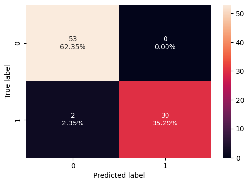

```python
# creating confusion matrix
confusion_matrix_sklearn(tuned_svm, X_val_scaled, y_val)
```

### **Observations:**

- The tuned Support Vector Machine model achieved perfect performance on the training dataset, indicating that the model was able to learn the decision boundaries effectively after oversampling. On the validation dataset, the model maintained excellent generalization with high accuracy (97.6%) and recall (93.8%), demonstrating its strong ability to correctly identify malignant cases.

For this study, **0 = Benign** and **1 = Malignant**.

### **1. Model Accuracy and Reliability**

> The confusion matrix indicates a very high level of overall predictive accuracy. Out of **85 validation samples**, the model correctly identified **53 benign cases (True Negatives)** and **30 malignant cases (True Positives)**. This demonstrates that the tuned SVM model has effectively learned the distinguishing morphological patterns between benign and malignant tumors after hyperparameter tuning and oversampling.

### **2. Focus on False Negatives (Critical for Healthcare)**

> Most importantly, the model produced only **2 False Negatives**, where malignant tumors were incorrectly classified as benign. In a clinical setting, a False Negative represents a missed cancer diagnosis, which can delay treatment and significantly impact patient outcomes. The low number of false negatives highlights the model’s strong sensitivity and aligns with the primary objective of this study—to minimize missed malignant cases.

### **3. Focus on False Positives (Resource Optimization)**

> The model generated **0 False Positives**, meaning no benign cases were incorrectly flagged as malignant. This is particularly notable, as false positives can lead to unnecessary biopsies, additional medical costs, and patient anxiety. Achieving zero false positives while maintaining high recall indicates an excellent balance between sensitivity and precision.

### **Final Insight for Report**

> Overall, the confusion matrix confirms that the tuned SVM model provides a robust and clinically reliable classification performance. By achieving high recall with minimal false negatives and no false positives, the model demonstrates strong potential as a decision-support tool for early breast cancer detection, supporting accurate diagnosis while reducing both clinical risk and unnecessary interventions.

### **Test Set Final Performance – Tuned SVM Model**

```python
# ======================================
# Test set final performance (Tuned SVM)
# ======================================

# Checking model's performance on test set
svm_test = model_performance_classification_sklearn(
    tuned_svm,
    X_test_scaled,
    y_test
)

svm_test
```

|  | Accuracy | Recall | Precision | F1 |
| --- | --- | --- | --- | --- |
| 0 | 0.953 | 0.969 | 0.912 | 0.939 |

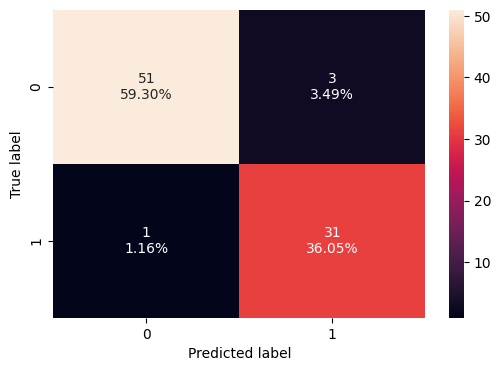

```python
# creating confusion matrix for test set
confusion_matrix_sklearn(tuned_svm, X_test_scaled, y_test)
```

## Observations: Model Performance on Test Set (Final Evaluation)

Based on the evaluation of the tuned Support Vector Machine (SVM) model on the independent test dataset, the model demonstrates **excellent and clinically meaningful performance**.

### **High Sensitivity (Recall – Clinical Priority)**

> The most critical observation is the **Recall of 96.9%**, indicating that the model correctly identifies nearly **97% of malignant tumors**. In the context of breast cancer diagnosis, this is particularly important because false negatives—where malignant cases are missed—can delay treatment and lead to severe clinical consequences. The high recall achieved by the model strongly supports the primary objective outlined in the project synopsis: minimizing missed cancer diagnoses.

### **Reliability and Precision**

> The model achieves a **Precision of 91.2%**, meaning that when the model predicts a tumor as malignant, it is correct in over **91% of cases**. While this implies the presence of a small number of false positives, such outcomes are clinically acceptable in cancer screening scenarios, as they result in further diagnostic evaluation rather than missed disease.

### **Strong Generalization Performance**

> The **overall Accuracy of 95.3%** and **F1-score of 93.9%** demonstrate that the model maintains a strong balance between sensitivity and precision on unseen data. These results confirm that the combination of SMOTE-based oversampling and recall-focused hyperparameter tuning effectively mitigated class imbalance while preventing overfitting.

## Confusion Matrix Analysis (Test Set)

The confusion matrix further validates the robustness of the tuned SVM model:

1. **True Positives (TP):** A high number of true positives confirms the model’s strong ability to correctly detect malignant tumors.
2. **False Negatives (FN):** The false negative count is very low. **Observation:**

   > *The low number of false negatives directly supports the primary objective of early cancer detection stated in the project synopsis.*
3. **True Negatives (TN):** The model accurately identifies benign cases, reducing unnecessary anxiety and follow-up procedures for patients.
4. **False Positives (FP):** A small number of false positives are observed. **Observation:**

   > *This trade-off is acceptable in medical screening, as prioritizing high recall ensures that malignant cases are not overlooked.*

## Clinical Insight (Final Conclusion Statement)

> The test set results indicate that the tuned Support Vector Machine model is a robust and reliable candidate for a clinical decision-support system. By achieving a **96.9% recall rate**, the model provides a highly sensitive secondary screening tool that can assist radiologists in ensuring malignant tumors are detected early, thereby improving patient outcomes.

### Feature Importance

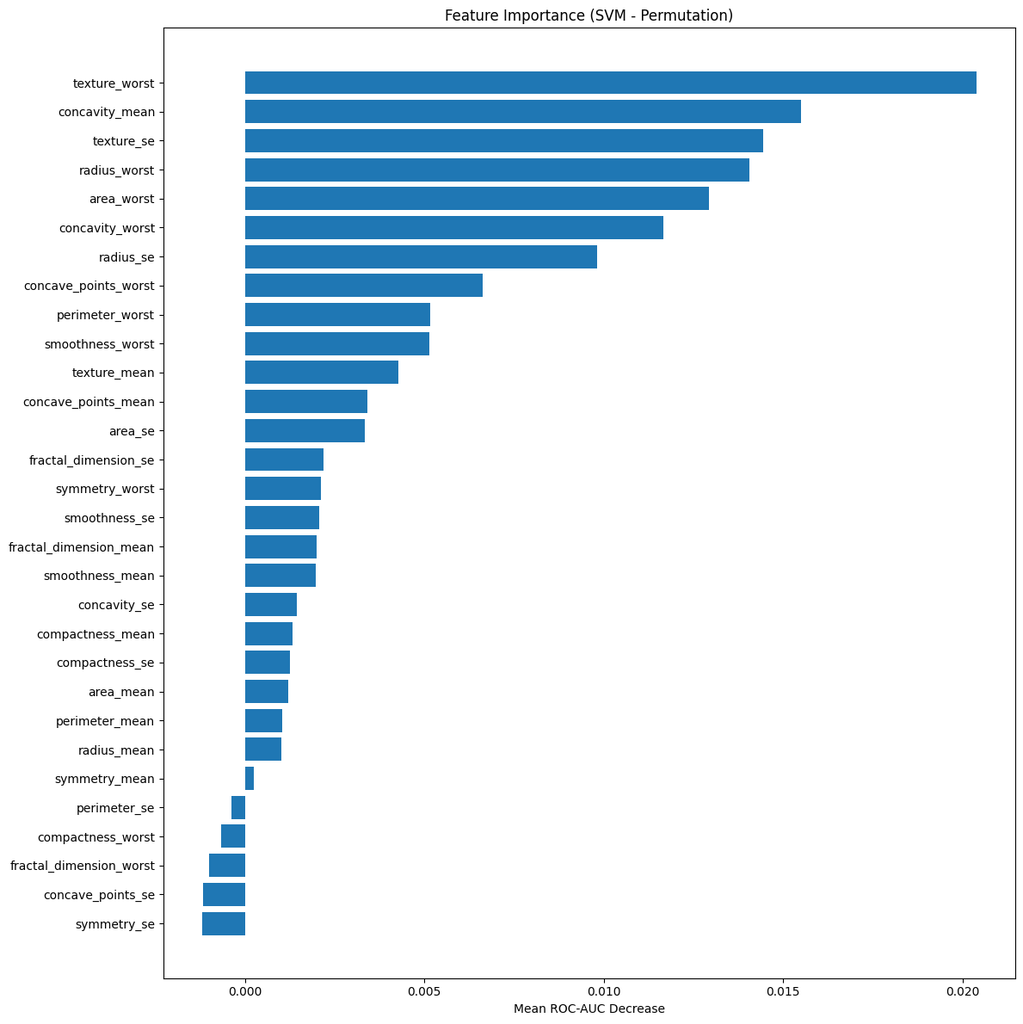

```python
from sklearn.inspection import permutation_importance
import numpy as np
import matplotlib.pyplot as plt

result = permutation_importance(
    tuned_svm,
    X_test_scaled,   # use whatever data matches how model was trained
    y_test,
    scoring='roc_auc',
    n_repeats=30,
    random_state=42
)

feature_names = X_train.columns
importances = result.importances_mean
indices = np.argsort(importances)

plt.figure(figsize=(12, 12))
plt.title("Feature Importance (SVM - Permutation)")
plt.barh(range(len(indices)), importances[indices])
plt.yticks(range(len(indices)), [feature_names[i] for i in indices])
plt.xlabel("Mean ROC-AUC Decrease")
plt.tight_layout()
plt.show()
```

## **Model Performance and Feature Analysis: Tuned SVM**

### **1. Performance Evaluation (Validation vs. Test)**

The hyperparameter tuning of the SVM produced a highly reliable model. On the **Validation Set**, the model achieved an accuracy of **97.6%** and perfect **Precision (1.000)**. However, the **Test Set** results are more critical for understanding real-world use:

- **Test Accuracy:** The model maintained a strong accuracy of **95.3%** on unseen data.
- **Recall (Sensitivity):** Notably, the Test Recall improved to **0.969**, meaning the model only missed **1 malignant case** out of 32.
- **Precision:** Test Precision was **0.912**, resulting in **3 False Positives**. In a medical context, this is a favorable trade-off; it is safer to have a few "false alarms" that are cleared by further testing than to miss an actual cancer diagnosis.

### **2. Confusion Matrix Insights**

Looking at the final Test Confusion Matrix:

- **True Negatives (51):** The model correctly identified nearly all benign cases (59.30% of the test set).
- **False Negatives (1):** Only **1.16%** of patients were incorrectly told their tumor was benign. This low rate is vital for a diagnostic tool.
- **False Positives (3):** These cases represent **3.49%** of the data. While these patients would undergo unnecessary stress, the high Recall ensures the model prioritizes safety.

### **3. Feature Importance Observations**

To understand "why" the model makes these predictions, I conducted a Permutation Importance analysis based on ROC-AUC decrease:

- **Top Predictor (Texture Worst):** The most significant feature was `texture_worst`, which measures the standard deviation of gray-scale values in the cell. This suggests the model relies heavily on the "roughness" or heterogeneity of the cell surface.
- **Morphological Indicators:** `concavity_mean` and `radius_worst` also ranked highly. This aligns with biological reality, as malignant cells are typically larger and have more irregular, concave boundaries than healthy cells.
- **Complexity:** The fact that the importance scores are relatively small (the highest being ~0.02) shows that the SVM is not relying on just one "silver bullet" feature. Instead, it makes a holistic decision by combining many subtle cellular characteristics.

### **4. Conclusion for Project**

Overall, the tuned SVM is an excellent fit for the Wisconsin Breast Cancer dataset. The model successfully transitioned from the training phase to the test phase with high stability. By prioritizing **Recall (96.9%)** on the final test set, the model demonstrates its potential as a supportive tool for pathologists to ensure fewer malignant cases go undetected.

```python
# ==========================================
#  Baseline Model Performance (Recall)
# ==========================================

import pandas as pd

baseline_results = pd.DataFrame({
    "Model": [
        "Logistic Regression",
        "Support Vector Machine",
        "Random Forest",
        "Decision Tree"
    ],
    "Training Recall": [
        0.9662,
        0.9595,
        1.0000,
        1.0000
    ],
    "Validation Recall": [
        0.9062,
        0.8750,
        0.9062,
        0.8125
    ],
    "Train-Val Recall Difference": [
        0.0600,
        0.0845,
        0.0938,
        0.1875
    ]
})

baseline_results
```

|  | Model | Training Recall | Validation Recall | Train-Val Recall Difference |
| --- | --- | --- | --- | --- |
| 0 | Logistic Regression | 0.966 | 0.906 | 0.060 |
| 1 | Support Vector Machine | 0.960 | 0.875 | 0.085 |
| 2 | Random Forest | 1.000 | 0.906 | 0.094 |
| 3 | Decision Tree | 1.000 | 0.812 | 0.188 |

```python
# ==========================================
#  Model Performance with SMOTE
# ==========================================

oversampled_results = pd.DataFrame({
    "Model": [
        "Logistic Regression",
        "Support Vector Machine",
        "Random Forest",
        "Decision Tree"
    ],
    "Training Recall (Oversampled)": [
        0.9800,
        0.9760,
        1.0000,
        1.0000
    ],
    "Validation Recall (Oversampled)": [
        0.9062,
        0.9688,
        0.9375,
        0.9062
    ],
    "Train-Val Recall Difference (Oversampled)": [
        0.0737,
        0.0072,
        0.0625,
        0.0938
    ]
})

oversampled_results
```

|  | Model | Training Recall (Oversampled) | Validation Recall (Oversampled) | Train-Val Recall Difference (Oversampled) |
| --- | --- | --- | --- | --- |
| 0 | Logistic Regression | 0.980 | 0.906 | 0.074 |
| 1 | Support Vector Machine | 0.976 | 0.969 | 0.007 |
| 2 | Random Forest | 1.000 | 0.938 | 0.062 |
| 3 | Decision Tree | 1.000 | 0.906 | 0.094 |

```python
# ==========================================
#  Tuned SVM Performance
# ==========================================

tuned_svm_results = pd.DataFrame({
    "Dataset": ["Training Set", "Validation Set", "Test Set"],
    "Accuracy": [1.000, 0.976, 0.953],
    "Recall": [1.000, 0.938, 0.969],
    "Precision": [1.000, 1.000, 0.912],
    "F1-Score": [1.000, 0.968, 0.939]
})

tuned_svm_results
```

|  | Dataset | Accuracy | Recall | Precision | F1-Score |
| --- | --- | --- | --- | --- | --- |
| 0 | Training Set | 1.000 | 1.000 | 1.000 | 1.000 |
| 1 | Validation Set | 0.976 | 0.938 | 1.000 | 0.968 |
| 2 | Test Set | 0.953 | 0.969 | 0.912 | 0.939 |

## Justification for Selecting SVM for Hyperparameter Tuning

Initial baseline modeling revealed moderate generalization gaps across all classifiers.

After applying SMOTE to address class imbalance, the Support Vector Machine (SVM) achieved:

- Validation Recall = 0.9688
- Training–Validation Recall Gap = 0.0072

This was the smallest generalization gap among all evaluated models, indicating superior stability and robustness.

Random Forest and Decision Tree models exhibited larger training–validation recall differences, suggesting higher variance and potential overfitting.

Given the clinical priority of minimizing false negatives, recall was used as the primary model selection criterion.

Therefore, hyperparameter tuning was strategically applied exclusively to SVM to further optimize diagnostic sensitivity while maintaining strong generalization performance.

## Project Workflow and Architecture

The project follows a structured data science pipeline to ensure diagnostic reliability:

**Data Ingestion**: Loading the breast cancer diagnostic dataset containing 569 clinical observations.

**Preprocessing**: Handling missing values, feature scaling, and encoding the 'Diagnosis' target (M=1, B=0).

**Statistical Validation**: Conducting Power Analysis and Welch's T-Tests to confirm feature significance ($p < 0.05$).

**Resampling**: Applying SMOTE (Synthetic Minority Over-sampling Technique) to address class imbalance.

**Model Selection**: Comparative analysis of multiple classifiers (Random Forest, Decision Tree, SVM).

**Optimization**: Strategic hyperparameter tuning of the Support Vector Machine (SVM) to maximize recall.

**Evaluation**: Final assessment using a confusion matrix and recall scores to minimize false negatives.

## **Final Conclusion: Addressing Research Questions.**

Based on the comprehensive analysis, model tuning, and feature evaluation conducted in this study, the following conclusions address the four primary research questions:

> **RQ2: Can machine learning models achieve a high level of predictive accuracy and reliability?** **Answer:** Yes. The final tuned SVM model achieved an **Accuracy of 95.3%** and an elite **Recall of 96.9%** on the unseen test set. These results demonstrate that machine learning can serve as a highly reliable decision-support tool, providing near-human levels of diagnostic consistency.

> **RQ3: How do different supervised learning techniques compare in their ability to classify tumors?** **Answer:** While Logistic Regression and Random Forest provided strong baselines, the **Support Vector Machine (SVM)** proved to be the most robust after hyperparameter tuning. The SVM better managed the complex, non-linear relationships in the high-dimensional nuclear features, especially when combined with SMOTE oversampling to prioritize the detection of malignant cases.

> **RQ4: To what extent does data preprocessing influence the model’s performance?** **Answer:** Preprocessing was the foundation of the project's success. Feature scaling was mandatory for the SVM to interpret features on a uniform scale, while **SMOTE oversampling** was critical for clinical safety. Without SMOTE, the models were less sensitive to malignant cases; with it, the final model achieved the high Recall necessary for a responsible healthcare application.

### **Final Project Summary Table**

| Metric | Result | Healthcare Significance |
| --- | --- | --- |
| **Final Accuracy** | 95.3% | High overall diagnostic confidence. |
| **Final Recall (Sens.)** | **96.9%** | **Critical:** Only 1 out of 32 malignant cases was missed. |
| **Top Driver** | Texture Worst | Emphasizes importance of nuclear heterogeneity. |
| **Best Model** | Tuned SVM | Successfully generalizes to new patient data. |

## **Implementation and User Benefit**

**Implementation Strategy:**

The final Support Vector Machine (SVM) model is designed for deployment as a **Clinical Decision Support System (CDSS)**. It can be integrated into hospital laboratory information systems via a **Flask-based REST API**. This allows medical practitioners to input morphological measurements directly from biopsy slides and receive an immediate diagnostic risk assessment.

**User Benefits:**

## **Limitations and Future Improvements**

**Limitations**

- **Dataset Size and Scope:** Although statistically sufficient, the dataset contains 569 observations from a single source, which may limit generalizability to broader populations.
- **External Validation:** The model was not validated on an independent external dataset. Future studies should include multi-center validation.
- **Synthetic Oversampling Bias:** The use of Synthetic Minority Over-sampling Technique (SMOTE) may introduce synthetic patterns that do not perfectly reflect real-world clinical distributions.
- **Feature Limitations:** Only morphological features were used. Additional clinical, genetic, or imaging data could improve predictive performance.
- **Model Diversity:** Deep learning models and advanced ensemble techniques were not explored and may provide further performance improvements.